# Loan Repayment Challenge

1. Problem domain
2. Understand the problem
3. Import libraries and datasets
4. Basic Data Exploration
5. Deeper Data Exploration
6. Feature Engineering
7. Data Preprocessing
8. Model Building and Evaluation
9. Export the Model
10. Final Notes

## Problem domain

[go back to the top]

### Introduction

At MoneyLion we are constantly working to assess the risk of our applicants more accurately. Being successful in this objective enables us to better price customers and mitigate losses on our portfolio of loans. The following challenge asks you to work with a dataset of loan repayment. It is intentionally meant to be open-ended. The point is not to arrive at a predetermined answer or search for the lowest possible standard error. Rather, the hope is that it will force you to ask relevant questions about the data, do some preliminary exploration, perform the necessary manipulations or aggregations, generate visualizations, and reach conclusions or insights.

### Data

You are provided with 3 files: loan.csv, payment.csv, and clarity_underwriting_variables.csv. The files are comma-separated, with the column names in the first row. The detailed description of each column is available in the MoneyLion Data Scientist Assessment Data Dictionary document. This can be found in the dictionaries.zip file.

### Guildelines

In this assessment, we do not expect a model built (feel free to attempt if you want to), but we want to see a proposal or plan around how you would approach the problem of predicting loan risk or quality (loan repayment) on a given loan application. Before diving into developing a plan, start with some exploratory data analysis (EDA). Take a look at some distributions of some of the variates. Think about how would you define a loan as risky. How would you select your sample if you were to build this model? Back your proposal with some EDA and insights you discovered from the data.

## Understand the problem

[go back to the top]

From the problem domain, the objective is to **access the risk of applicants more accurately**. With this objective, it is allowed but not limited to perform:

- Data preparation
- Data exploration
- Data visualization
- Model building

## Import libraries and datasets

[go back to the top]

```python
# import all libraries

import numpy as np
import pandas as pd
import matplotlib as mlt
import matplotlib.pyplot as plt
import seaborn as sns
import sklearn
import xgboost
import joblib

%matplotlib inline
```

```python
# print out libraries version

print('numpy:',np.__version__)
print('pandas:',pd.__version__)
print('matplotlib:',mlt.__version__)
print('seaborn:',sns.__version__)
print('scikit-learn:',sklearn.__version__)
print('xgboost:',xgboost.__version__)
print('joblib',joblib.__version__)
```

```
numpy: 1.21.0
pandas: 1.3.0
matplotlib: 3.4.2
seaborn: 0.11.1
scikit-learn: 0.24.2
xgboost: 1.6.1
joblib 1.1.0
```

```python
# import the relevant datasets

df_loan_path = 'data/data/loan.csv'
df_payment_path = 'data/data/payment.csv'
df_underwriting_path = 'data/data/clarity_underwriting_variables.csv'

df_loan = pd.read_csv(df_loan_path, parse_dates=["applicationDate", "originatedDate"])
df_payment = pd.read_csv(df_payment_path, parse_dates=["paymentDate"])
df_underwriting = pd.read_csv(df_underwriting_path);
```

### Basic Data Exploration

[go back to the top]

First, I will get the overall information for all three separate datasets, starting from `df_loan` dataset.

```python
df_loan_info = df_loan.describe(include='all', datetime_is_numeric=True)

df_loan_info.loc['dtype'] = df_loan.dtypes
df_loan_info.loc['null'] = df_loan.isna().sum()
df_loan_info.loc['% null'] = df_loan.isna().mean()

df_loan_info
```

|  | loanId | anon_ssn | payFrequency | apr | applicationDate | originated | originatedDate | nPaidOff | approved | isFunded | loanStatus | loanAmount | originallyScheduledPaymentAmount | state | leadType | leadCost | fpStatus | clarityFraudId | hasCF |
| --- | --- | --- | --- | --- | --- | --- | --- | --- | --- | --- | --- | --- | --- | --- | --- | --- | --- | --- | --- |
| count | 577426 | 577682 | 576409 | 573760.0 | 577682 | 577682 | 46044 | 577658.0 | 577682 | 577682.0 | 577291 | 575432.0 | 577682.0 | 577550 | 577682 | 577682.0 | 51723 | 357693 | 577682.0 |
| unique | 577426 | 459393 | 5 | NaN | NaN | 2 | NaN | NaN | 2 | NaN | 21 | NaN | NaN | 44 | 10 | NaN | 8 | 314915 | NaN |
| top | LL-I-07399092 | c8bb49de1f8ff99d2ecddfb7037dc66e | B | NaN | NaN | False | NaN | NaN | False | NaN | Withdrawn Application | NaN | NaN | OH | bvMandatory | NaN | Checked | 561e95f7e4b0efa8a6cdc975 | NaN |
| freq | 1 | 35 | 316654 | NaN | NaN | 531676 | NaN | NaN | 537646 | NaN | 450984 | NaN | NaN | 90496 | 475001 | NaN | 32978 | 15 | NaN |
| mean | NaN | NaN | NaN | 553.080972 | 2016-06-20 01:28:37.156051712 | NaN | 2016-07-21 00:54:31.797064704 | 0.037887 | NaN | 0.06748 | NaN | 514.245084 | 1428.897209 | NaN | NaN | 7.854389 | NaN | NaN | 0.619187 |
| min | NaN | NaN | NaN | 0.0 | 2014-12-03 00:31:22.306000 | NaN | 2014-12-02 17:47:22 | 0.0 | NaN | 0.0 | NaN | 0.0 | -816.71 | NaN | NaN | 0.0 | NaN | NaN | 0.0 |
| 25% | NaN | NaN | NaN | 490.0 | 2016-01-16 19:21:23.498499840 | NaN | 2016-01-15 20:37:59.800000 | 0.0 | NaN | 0.0 | NaN | 350.0 | 1023.64 | NaN | NaN | 3.0 | NaN | NaN | 0.0 |
| 50% | NaN | NaN | NaN | 590.0 | 2016-06-23 10:27:59.915500032 | NaN | 2016-10-20 19:58:20.797000192 | 0.0 | NaN | 0.0 | NaN | 500.0 | 1245.25 | NaN | NaN | 3.0 | NaN | NaN | 1.0 |
| 75% | NaN | NaN | NaN | 601.0 | 2016-12-19 17:55:08.820750080 | NaN | 2017-01-11 17:46:46.808999936 | 0.0 | NaN | 0.0 | NaN | 500.0 | 1615.66 | NaN | NaN | 6.0 | NaN | NaN | 1.0 |
| max | NaN | NaN | NaN | 705.59 | 2017-03-18 23:58:42.921000 | NaN | 2017-03-27 20:56:08.598000 | 21.0 | NaN | 1.0 | NaN | 5000.0 | 19963.63 | NaN | NaN | 200.0 | NaN | NaN | 1.0 |
| std | NaN | NaN | NaN | 110.046159 | NaN | NaN | NaN | 0.333366 | NaN | 0.250852 | NaN | 320.939929 | 925.009141 | NaN | NaN | 12.853451 | NaN | NaN | 0.485587 |
| dtype | object | object | object | float64 | datetime64[ns] | bool | datetime64[ns] | float64 | bool | int64 | object | float64 | float64 | object | object | int64 | object | object | int64 |
| null | 256 | 0 | 1273 | 3922 | 0 | 0 | 531638 | 24 | 0 | 0 | 391 | 2250 | 0 | 132 | 0 | 0 | 525959 | 219989 | 0 |
| % null | 0.000443 | 0.0 | 0.002204 | 0.006789 | 0.0 | 0.0 | 0.920295 | 0.000042 | 0.0 | 0.0 | 0.000677 | 0.003895 | 0.0 | 0.000228 | 0.0 | 0.0 | 0.910465 | 0.380813 | 0.0 |

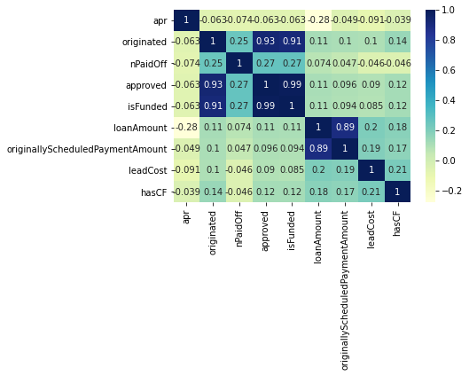

```python
# correlation map
sns.heatmap(df_loan.corr(), cmap="YlGnBu", annot=True)
```

From the correlation map, `originated`, `approved` and `isFunded` are highly correlated. This is true as if the loan is not originated, it is not going to be approved and funded. Besides, `loanAmount` and `originallyScheduledPaymentAmount` are highly correlated also as the higher the loan amount, the higher the original scheduled of payment amount.

```python
filter = ~df_loan.originatedDate.isna() & (df_loan.originated == False)
df_loan.loc[filter]
```

|  | loanId | anon_ssn | payFrequency | apr | applicationDate | originated | originatedDate | nPaidOff | approved | isFunded | loanStatus | loanAmount | originallyScheduledPaymentAmount | state | leadType | leadCost | fpStatus | clarityFraudId | hasCF |
| --- | --- | --- | --- | --- | --- | --- | --- | --- | --- | --- | --- | --- | --- | --- | --- | --- | --- | --- | --- |
| 6971 | LL-I-00506530 | cbf5d8b04f5e6603cc95dfe4e1238244 | W | 490.00 | 2015-03-29 01:03:43.092 | False | 2015-04-01 20:42:49.415 | 0.0 | False | 0 | Withdrawn Application | 800.0 | 2098.10 | SC | bvMandatory | 3 | NaN | NaN | 0 |
| 33610 | LL-I-04395289 | 2092077960a8685e4cd1b60c3c682111 | B | 681.00 | 2015-11-06 20:52:24.877 | False | 2015-11-06 21:07:04.360 | 0.0 | False | 0 | Withdrawn Application | 300.0 | 883.60 | OH | prescreen | 0 | NaN | 563d1af9e4b03fcc6c43fa5a | 1 |
| 47779 | LL-I-06197657 | 72bd6de76cfe9481913a4c28b2b53b06 | B | 601.00 | 2016-01-01 02:09:56.317 | False | 2016-01-11 23:59:06.758 | 0.0 | False | 0 | Withdrawn Application | 800.0 | 2469.99 | SC | bvMandatory | 10 | NaN | 569432fce4b08fd46ba3205a | 1 |
| 50204 | LL-I-00809206 | 61dcc3f917ea928e974c9e9de119fbfc | B | 390.00 | 2015-04-23 16:13:39.083 | False | 2015-04-23 20:52:40.233 | 0.0 | False | 0 | Withdrawn Application | 300.0 | 662.95 | WI | bvMandatory | 6 | NaN | NaN | 0 |
| 74230 | LL-I-04924584 | ea7c3a6d5ca8b65fdb74e731c3597416 | B | 650.00 | 2015-11-23 19:01:26.528 | False | 2015-11-24 04:11:44.684 | 0.0 | False | 0 | Withdrawn Application | 350.0 | 1108.86 | TN | bvMandatory | 3 | NaN | 5653807de4b05a02c1a24e56 | 1 |
| 78103 | LL-I-06823822 | 43168c6ab4422b27506bbaad47a0e80e | W | 650.00 | 2016-01-27 00:21:27.066 | False | 2016-01-27 05:33:12.825 | 0.0 | False | 0 | Withdrawn Application | 250.0 | 808.39 | TN | bvMandatory | 10 | NaN | 56a81031e4b0d9d0af792c28 | 1 |
| 85081 | LL-I-06865629 | d923b3f10d237bc80f4e5d7f34e95bd7 | B | 360.00 | 2016-01-28 17:42:10.387 | False | 2016-02-02 17:40:07.887 | 0.0 | False | 0 | Withdrawn Application | 350.0 | 748.51 | IL | bvMandatory | 10 | NaN | 56aaae34e4b0929480df9b2f | 1 |
| 94413 | LL-I-00244412 | bbe966237373d1b58389888bf0c4bf6d | M | 490.00 | 2015-02-16 18:54:01.803 | False | 2015-02-17 01:11:57.255 | 0.0 | False | 0 | Withdrawn Application | 300.0 | 1435.94 | MO | bvMandatory | 3 | NaN | NaN | 0 |
| 108448 | LL-I-02866184 | b99295ee0f6b17de30c9b6adb021e9f7 | B | 0.00 | 2015-08-31 22:33:18.694 | False | 2015-09-01 20:40:41.485 | 0.0 | False | 0 | Withdrawn Application | 0.0 | 0.00 | SC | bvMandatory | 10 | NaN | NaN | 0 |
| 121045 | LL-I-04859658 | f9bb0b0d3332ec167d77e1736a12decc | W | 625.00 | 2015-11-21 13:26:12.925 | False | 2015-11-22 01:29:41.929 | 0.0 | False | 0 | Withdrawn Application | 350.0 | 1101.94 | OH | bvMandatory | 3 | NaN | 56507263e4b05a02bf6d1d85 | 1 |
| 125718 | LL-I-00203828 | 956d0b7e1c7ba5e21d96fea4929f3eb9 | W | 570.32 | 2015-01-31 17:20:48.830 | False | 2015-02-02 16:41:14.494 | 0.0 | True | 0 | Withdrawn Application | 300.0 | 832.83 | OH | bvMandatory | 3 | NaN | NaN | 0 |
| 141600 | LL-I-00186985 | 882db5ef15649c675d086bfe89ea9533 | M | NaN | 2015-01-26 21:10:23.311 | False | 2015-01-27 13:51:14.119 | 0.0 | False | 0 | Withdrawn Application | 600.0 | 2699.95 | OH | bvMandatory | 3 | NaN | NaN | 0 |
| 156741 | LL-I-08006986 | 0adef859cf6b09b9fde41c2cff6de21a | B | 449.99 | 2016-03-21 18:41:37.866 | False | 2016-03-21 19:30:26.962 | 0.0 | False | 0 | Credit Return Void | 600.0 | 1427.42 | NV | lead | 75 | NaN | 56f0405ae4b078dd3993fa3f | 1 |
| 176193 | LL-I-02844527 | 671326ef3ca35856783308d91e1b7779 | B | 449.99 | 2015-08-31 12:39:26.824 | False | 2015-08-31 20:21:06.961 | 0.0 | False | 0 | Withdrawn Application | 400.0 | 1002.04 | WI | bvMandatory | 6 | NaN | NaN | 0 |
| 177605 | LL-I-07410265 | ea939d70cbaba1c87e788ace28ae3e9a | W | 525.00 | 2016-02-24 01:55:53.172 | False | 2016-02-24 14:42:26.949 | 0.0 | False | 0 | Withdrawn Application | 600.0 | 1639.02 | SD | bvMandatory | 3 | NaN | 56cd0e8de4b0cfcbc18295b5 | 1 |
| 193629 | LL-I-00235967 | 03397998696a3a153a20a12fa6393410 | M | 590.00 | 2015-02-12 23:25:32.922 | False | 2015-02-13 03:30:18.800 | 0.0 | False | 0 | Withdrawn Application | 300.0 | 1730.28 | OH | organic | 0 | NaN | NaN | 0 |
| 196428 | LL-I-00169700 | 9ce0ef32c28cde97995b7d596c52013e | B | NaN | 2015-01-22 18:20:54.349 | False | 2015-01-22 20:06:40.927 | 0.0 | False | 0 | Withdrawn Application | 400.0 | 1160.28 | OH | bvMandatory | 3 | NaN | NaN | 0 |
| 205827 | LL-I-00376357 | 49bf748b62323d4efd5e1e5c7af93dfc | B | 525.00 | 2015-03-14 18:06:10.868 | False | 2015-03-16 17:08:40.377 | 0.0 | False | 0 | Withdrawn Application | 300.0 | 815.51 | OH | bvMandatory | 3 | NaN | NaN | 0 |
| 223405 | LL-I-06294835 | aaaaf924bf64b23b0eebb25c33575154 | B | 590.00 | 2016-01-07 02:39:22.041 | False | 2016-01-07 22:54:58.114 | 0.0 | False | 0 | Withdrawn Application | 400.0 | 1079.34 | OH | bvMandatory | 6 | NaN | 568eec6fe4b08fd46869e036 | 1 |
| 230624 | LL-I-06554489 | 411a5fd6e01d7933b00117dbcaa3dfd2 | B | 625.00 | 2016-01-16 13:50:29.815 | False | 2016-01-19 23:16:28.187 | 0.0 | False | 0 | Withdrawn Application | 350.0 | 1153.78 | MI | bvMandatory | 6 | NaN | 569a4c8ce4b096699c8eb11e | 1 |
| 260643 | LL-I-02713917 | b7a9fb1f2705a19b0d30c766257c7e0c | W | 601.00 | 2015-08-25 14:08:38.098 | False | 2015-08-25 14:16:10.317 | 0.0 | False | 0 | Withdrawn Application | 800.0 | 2438.78 | SC | bvMandatory | 6 | NaN | 55dc7873e4b0ddd31fd7b48b | 1 |
| 299514 | LL-I-07864934 | 57d4761ba96d705160853cf5240e98fa | B | 681.00 | 2016-03-15 16:59:49.690 | False | 2016-03-15 19:21:11.393 | 0.0 | False | 0 | Withdrawn Application | 300.0 | 1023.64 | IN | bvMandatory | 3 | NaN | 56e840eae4b0a9e4ca347d29 | 1 |
| 309087 | LL-I-08194005 | 028fc92ec5b4da2ee4c9374ca9475753 | W | 562.50 | 2016-03-29 01:57:25.491 | False | 2016-04-06 19:33:36.909 | 1.0 | False | 0 | Withdrawn Application | 468.0 | 1416.24 | IN | lead | 40 | NaN | 565bb76ce4b0819f39d4231f | 1 |
| 334600 | LL-I-00632184 | 491ba5e2ab147bc22f3c762b2e0250aa | M | 475.00 | 2015-04-08 13:20:28.719 | False | 2015-04-08 13:55:42.108 | 0.0 | False | 0 | Customer Voided New Loan | 300.0 | 761.38 | OH | bvMandatory | 6 | NaN | NaN | 0 |
| 380259 | LL-I-00155220 | 8fadbf14436dcf90ec6ca2d4b654b693 | W | NaN | 2015-01-19 20:50:02.665 | False | 2015-01-20 14:06:41.860 | 0.0 | False | 0 | Withdrawn Application | 500.0 | 1219.46 | OH | bvMandatory | 3 | NaN | NaN | 0 |
| 396908 | LL-I-01316991 | 7ea91e7b7f41c3a8bb77fe4c36e7fbca | W | 590.00 | 2015-05-26 17:14:46.438 | False | 2015-05-26 20:36:59.163 | 0.0 | False | 0 | Withdrawn Application | 300.0 | 901.72 | TX | organic | 6 | NaN | 5547fd60e4b0bd919792b2b9 | 1 |
| 397850 | LL-I-06357807 | e82f0284ca0b4e9e8ba8d43b8504e8d3 | B | 601.00 | 2016-01-09 14:23:46.302 | False | 2016-01-09 14:33:38.666 | 0.0 | False | 0 | Withdrawn Application | 600.0 | 1809.91 | SC | bvMandatory | 10 | NaN | 569119efe4b08fd469ab0daf | 1 |
| 401495 | LL-I-02953631 | 30f740f02f3a0993adb0e805d66ecfb9 | W | 449.99 | 2015-09-04 14:35:53.410 | False | 2015-09-04 20:00:45.262 | 0.0 | False | 0 | Withdrawn Application | 800.0 | 1972.97 | WI | lead | 100 | NaN | 55e9ac45e4b09f9adbaa1fd0 | 1 |
| 421429 | LL-I-01934691 | c12851abede7ec3cb9fd2264bb16426b | B | 590.00 | 2015-07-27 18:56:24.271 | False | 2015-07-28 13:39:41.149 | 0.0 | False | 0 | Withdrawn Application | 400.0 | 1141.41 | MO | bvMandatory | 6 | NaN | NaN | 0 |
| 442136 | LL-I-08552489 | 824dfd60880983311d4f0163854a100f | B | 449.99 | 2016-04-09 03:58:43.025 | False | 2016-04-09 14:25:59.373 | 0.0 | False | 0 | Withdrawn Application | 400.0 | 1037.99 | UT | bvMandatory | 3 | NaN | 57087f2be4b06ef47f7ee50c | 1 |
| 447574 | LL-I-04852655 | ba194a8e0f06ac20fedc272a1fc91265 | S | 625.00 | 2015-11-21 01:00:31.062 | False | 2015-11-21 04:16:21.645 | 0.0 | False | 0 | Withdrawn Application | 400.0 | 1184.77 | MI | organic | 0 | NaN | 55461815e4b050e8bfe38186 | 1 |
| 449104 | LL-I-00235907 | 2ff8c6ca9d1fcdbcee4521ba729c7996 | W | 650.00 | 2015-02-12 22:58:43.148 | False | 2015-02-13 03:14:30.213 | 0.0 | True | 0 | Withdrawn Application | 300.0 | 956.28 | OH | bvMandatory | 3 | NaN | NaN | 0 |
| 489563 | LL-I-01625599 | 2be1a9af4b9ef919800983f2134ce0b8 | W | 490.00 | 2015-06-12 19:48:08.199 | False | 2015-06-25 18:22:16.465 | 0.0 | False | 0 | Withdrawn Application | 800.0 | 2040.61 | SC | bvMandatory | 6 | NaN | 55730bd6e4b0a03137267f55 | 1 |
| 526833 | LL-I-04625529 | b78a67023ee6377be4b4a0c2016107e3 | M | 681.00 | 2015-11-14 14:03:04.024 | False | 2015-11-17 23:08:15.116 | 0.0 | False | 0 | Withdrawn Application | 300.0 | 1069.85 | OH | prescreen | 0 | NaN | 56473f12e4b033d9d3c5b04f | 1 |
| 530526 | LL-I-04529399 | 798fcbe05a7e188517ac65456e16c4f9 | W | 601.00 | 2015-11-11 15:57:03.970 | False | 2015-11-11 16:06:20.899 | 0.0 | False | 0 | Credit Return Void | 600.0 | 1806.68 | NC | bvMandatory | 10 | NaN | 56436661e4b0f92a55aff2df | 1 |
| 544596 | LL-I-06678491 | 040d2547ec5ce04cf30d1cea869ba6ac | B | 251.00 | 2016-01-21 00:11:19.268 | False | 2016-01-21 14:56:23.515 | 0.0 | False | 0 | Withdrawn Application | 2600.0 | 6793.36 | CA | prescreen | 0 | NaN | 56a02222e4b09669a069eb22 | 1 |
| 568584 | LL-I-07325218 | aaa8cc1b5e41b9684fda0b2655a4babb | B | 590.00 | 2016-02-19 02:52:29.378 | False | 2016-02-22 16:48:13.636 | 0.0 | False | 0 | Withdrawn Application | 900.0 | 2463.77 | IN | lead | 40 | NaN | 5670cd2ee4b08b757983fea0 | 1 |
| 571665 | LL-I-05373367 | e8a969c88f195cdf16bd804d92379355 | B | 360.00 | 2015-12-06 04:02:10.046 | False | 2015-12-06 16:50:21.316 | 0.0 | False | 0 | Withdrawn Application | 325.0 | 641.00 | IL | organic | 0 | NaN | 5663b33ce4b0100e85366f5a | 1 |

From the dataframe above, it looks suspicious that `originated` is **`False`** since it is impossible that the loan is not originated but contains valid originated Date. Therefore, I would modify the `originated` to **`True`** for these columns.

```python
df_loan.loc[filter, 'originated'] = True
```

Next, I will move to `df_payment` dataset.

```python
df_payment_info = df_payment.describe(include='all', datetime_is_numeric=True)

df_payment_info.loc['dtype'] = df_payment.dtypes
df_payment_info.loc['null'] = df_payment.isna().sum()
df_payment_info.loc['% null'] = df_payment.isna().mean()

df_payment_info
```

|  | loanId | installmentIndex | isCollection | paymentDate | principal | fees | paymentAmount | paymentStatus | paymentReturnCode |
| --- | --- | --- | --- | --- | --- | --- | --- | --- | --- |
| count | 689364 | 689364.0 | 689364 | 689364 | 689364.0 | 689364.0 | 689364.0 | 689364 | 31533 |
| unique | 39952 | NaN | 2 | NaN | NaN | NaN | NaN | 9 | 31 |
| top | LL-I-12230332 | NaN | False | NaN | NaN | NaN | NaN | Cancelled | R01 |
| freq | 105 | NaN | 675469 | NaN | NaN | NaN | NaN | 270334 | 22866 |
| mean | NaN | 10.553222 | NaN | 2016-10-17 17:12:40.541038080 | 45.557543 | 67.003994 | 112.680232 | NaN | NaN |
| min | NaN | 1.0 | NaN | 2014-12-09 05:00:00 | -303.37 | -42.56 | -337.7 | NaN | NaN |
| 25% | NaN | 5.0 | NaN | 2016-04-29 04:00:00 | 13.18 | 28.82 | 56.81 | NaN | NaN |
| 50% | NaN | 9.0 | NaN | 2016-12-27 05:00:00 | 27.61 | 51.3 | 86.34 | NaN | NaN |
| 75% | NaN | 14.0 | NaN | 2017-04-14 04:00:00 | 53.38 | 86.44 | 135.09 | NaN | NaN |
| max | NaN | 105.0 | NaN | 2021-02-26 05:00:00 | 4000.0 | 1257.71 | 4063.6 | NaN | NaN |
| std | NaN | 8.04953 | NaN | NaN | 81.724683 | 59.78951 | 105.78371 | NaN | NaN |
| dtype | object | int64 | bool | datetime64[ns] | float64 | float64 | float64 | object | object |
| null | 0 | 0 | 0 | 0 | 0 | 0 | 0 | 0 | 657831 |
| % null | 0.0 | 0.0 | 0.0 | 0.0 | 0.0 | 0.0 | 0.0 | 0.0 | 0.954258 |

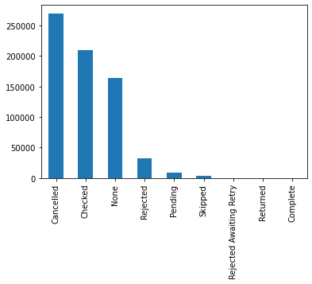

```python
# paymentStatus
df_payment.paymentStatus.value_counts().plot.bar()
```

From the graph, I will modify some of the data

1. Change `Complete` into `Checked`
2. Change `Returned` into `Rejected` (This [article](https://www.investopedia.com/terms/r/returned-payment-fee.asp#:~:text=The%20term%20returned%20payment%20fee,account%20closures%2C%20or%20account%20freezes.) explains about what is a returned payment.)

```python
condition1 = df_payment.paymentStatus == 'Complete'
condition2 = df_payment.paymentStatus == 'Returned'

df_payment.loc[condition1, 'paymentStatus'] = 'Checked'
df_payment.loc[condition2, 'paymentStatus'] = 'Rejected'
```

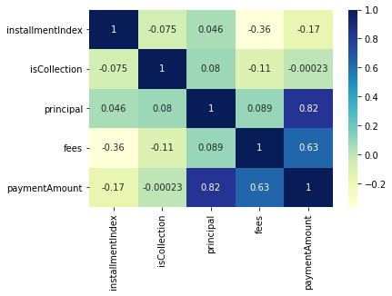

```python
# correlation map
sns.heatmap(df_payment.corr(), cmap="YlGnBu", annot=True)
```

From the correlation map above, `paymentAmount` is highly correlated with `principal` and `fees` columns (As payment amount usually equals to fees + principal).

Based on some basic exploration, I will extract `loanId`, `paymentAmount` and `paymentStatus` columns from this dataset.

- `loanId` - To merge with other datasets
- `paymentAmount` - Sum up total payment amount by each loan (`loanId`) if `paymentStatus` = **`Checked`**. This is the effective amount paid for each `loanId`
- `paymentStatus` - Sum up total count of different payment status for each `loanId`

```python
# payment amount
df_payment_amount = df_payment.loc[df_payment.paymentStatus == 'Checked', ['loanId','paymentAmount']].groupby('loanId').sum().reset_index()
df_payment_amount
```

|  | loanId | paymentAmount |
| --- | --- | --- |
| 0 | LL-I-00000021 | 1865.61 |
| 1 | LL-I-00000231 | 258.64 |
| 2 | LL-I-00000238 | 1162.60 |
| 3 | LL-I-00000308 | 61.59 |
| 4 | LL-I-00000419 | 226.31 |
| ... | ... | ... |
| 32163 | LP-I-00000109 | 1155.98 |
| 32164 | LP-I-00000127 | 872.52 |
| 32165 | LP-I-00000134 | 869.70 |
| 32166 | LP-I-00000139 | 910.25 |
| 32167 | LP-I-00000145 | 807.49 |

32168 rows × 2 columns

```python
# payment status
df_dummy_payment_status = pd.get_dummies(df_payment.paymentStatus, prefix='Status').join(df_payment.loanId)
df_payment_status = df_dummy_payment_status.groupby('loanId').sum().reset_index()
df_payment_status
```

|  | loanId | Status_Cancelled | Status_Checked | Status_None | Status_Pending | Status_Rejected | Status_Rejected Awaiting Retry | Status_Skipped |
| --- | --- | --- | --- | --- | --- | --- | --- | --- |
| 0 | LL-I-00000021 | 0 | 12 | 0 | 0 | 1 | 0 | 0 |
| 1 | LL-I-00000231 | 8 | 2 | 8 | 0 | 2 | 0 | 0 |
| 2 | LL-I-00000238 | 4 | 7 | 4 | 0 | 1 | 0 | 0 |
| 3 | LL-I-00000308 | 10 | 1 | 10 | 0 | 1 | 0 | 0 |
| 4 | LL-I-00000355 | 11 | 0 | 11 | 0 | 1 | 0 | 0 |
| ... | ... | ... | ... | ... | ... | ... | ... | ... |
| 39947 | LP-I-00000127 | 0 | 12 | 0 | 0 | 0 | 0 | 0 |
| 39948 | LP-I-00000134 | 6 | 1 | 0 | 0 | 0 | 0 | 0 |
| 39949 | LP-I-00000139 | 0 | 12 | 0 | 0 | 3 | 0 | 0 |
| 39950 | LP-I-00000142 | 12 | 0 | 0 | 0 | 0 | 0 | 1 |
| 39951 | LP-I-00000145 | 0 | 12 | 0 | 0 | 0 | 0 | 0 |

39952 rows × 8 columns

```python
# combine payment amount & payment status in a dataframe
df_payment_clean = df_payment_amount.merge(df_payment_status, how='right', on='loanId')
df_payment_clean
```

|  | loanId | paymentAmount | Status_Cancelled | Status_Checked | Status_None | Status_Pending | Status_Rejected | Status_Rejected Awaiting Retry | Status_Skipped |
| --- | --- | --- | --- | --- | --- | --- | --- | --- | --- |
| 0 | LL-I-00000021 | 1865.61 | 0 | 12 | 0 | 0 | 1 | 0 | 0 |
| 1 | LL-I-00000231 | 258.64 | 8 | 2 | 8 | 0 | 2 | 0 | 0 |
| 2 | LL-I-00000238 | 1162.60 | 4 | 7 | 4 | 0 | 1 | 0 | 0 |
| 3 | LL-I-00000308 | 61.59 | 10 | 1 | 10 | 0 | 1 | 0 | 0 |
| 4 | LL-I-00000355 | NaN | 11 | 0 | 11 | 0 | 1 | 0 | 0 |
| ... | ... | ... | ... | ... | ... | ... | ... | ... | ... |
| 39947 | LP-I-00000127 | 872.52 | 0 | 12 | 0 | 0 | 0 | 0 | 0 |
| 39948 | LP-I-00000134 | 869.70 | 6 | 1 | 0 | 0 | 0 | 0 | 0 |
| 39949 | LP-I-00000139 | 910.25 | 0 | 12 | 0 | 0 | 3 | 0 | 0 |
| 39950 | LP-I-00000142 | NaN | 12 | 0 | 0 | 0 | 0 | 0 | 1 |
| 39951 | LP-I-00000145 | 807.49 | 0 | 12 | 0 | 0 | 0 | 0 | 0 |

39952 rows × 9 columns

```python
pd.set_option('display.max_columns', None)

# rename underwriting column names
def rename_underwriting(x):
    return x.split('.')[-1]

df_underwriting = df_underwriting.rename(columns=rename_underwriting)

df_underwriting_info = df_underwriting.describe(include='all')

df_underwriting_info.loc['dtype'] = df_underwriting.dtypes
df_underwriting_info.loc['null'] = df_underwriting.isna().sum()
df_underwriting_info.loc['% null'] = df_underwriting.isna().mean()

df_underwriting_info
```

|  | thirtydaysago | twentyfourhoursago | oneminuteago | onehourago | ninetydaysago | sevendaysago | tenminutesago | fifteendaysago | threesixtyfivedaysago | inquiryonfilecurrentaddressconflict | totalnumberoffraudindicators | telephonenumberinconsistentwithaddress | inquiryageyoungerthanssnissuedate | onfileaddresscautious | inquiryaddressnonresidential | onfileaddresshighrisk | ssnreportedmorefrequentlyforanother | currentaddressreportedbytradeopenlt90days | inputssninvalid | inputssnissuedatecannotbeverified | inquiryaddresscautious | morethan3inquiriesinthelast30days | onfileaddressnonresidential | creditestablishedpriortossnissuedate | driverlicenseformatinvalid | inputssnrecordedasdeceased | inquiryaddresshighrisk | inquirycurrentaddressnotonfile | bestonfilessnissuedatecannotbeverified | … |
| --- | --- | --- | --- | --- | --- | --- | --- | --- | --- | --- | --- | --- | --- | --- | --- | --- | --- | --- | --- | --- | --- | --- | --- | --- | --- | --- | --- | --- | --- | --- |
| count | 49750.0 | 49750.0 | 49750.0 | 49750.0 | 49750.0 | 49750.0 | 49750.0 | 49750.0 | 49750.0 | 49712 | 49735.0 | 49712 | 49712 | 49712 | 49712 | 49712 | 49712 | 49712 | 49712 | 49712 | 49712 | 49712 | 49712 | 49712 | 44703 | 49712 | 49712 | 49712 | 49712 | … |
| unique | NaN | NaN | NaN | NaN | NaN | NaN | NaN | NaN | NaN | 2 | NaN | 2 | 2 | 2 | 2 | 2 | 2 | 2 | 1 | 2 | 2 | 2 | 2 | 2 | 2 | 1 | 2 | 2 | 1 | … |
| top | NaN | NaN | NaN | NaN | NaN | NaN | NaN | NaN | NaN | False | NaN | True | False | False | False | False | False | False | False | False | False | False | False | False | False | False | False | False | False | … |
| freq | NaN | NaN | NaN | NaN | NaN | NaN | NaN | NaN | NaN | 37474 | NaN | 45781 | 49569 | 49706 | 42437 | 49193 | 49141 | 48395 | 49712 | 49637 | 49700 | 47878 | 46302 | 49509 | 38732 | 49712 | 49108 | 44171 | 49712 | … |
| mean | 7.313628 | 4.60199 | 2.34398 | 4.006874 | 10.554513 | 5.423799 | 3.292121 | 6.155578 | 20.302291 | NaN | 2.118327 | NaN | NaN | NaN | NaN | NaN | NaN | NaN | NaN | NaN | NaN | NaN | NaN | NaN | NaN | NaN | NaN | NaN | NaN | … |
| std | 6.327122 | 3.302288 | 1.436345 | 2.697831 | 10.450845 | 4.110483 | 2.109667 | 4.95262 | 23.771239 | NaN | 1.254602 | NaN | NaN | NaN | NaN | NaN | NaN | NaN | NaN | NaN | NaN | NaN | NaN | NaN | NaN | NaN | NaN | NaN | NaN | … |
| min | 0.0 | 0.0 | 0.0 | 0.0 | 0.0 | 0.0 | 0.0 | 0.0 | 0.0 | NaN | 0.0 | NaN | NaN | NaN | NaN | NaN | NaN | NaN | NaN | NaN | NaN | NaN | NaN | NaN | NaN | NaN | NaN | NaN | NaN | … |
| 25% | 3.0 | 3.0 | 1.0 | 3.0 | 4.0 | 3.0 | 2.0 | 3.0 | 6.0 | NaN | 1.0 | NaN | NaN | NaN | NaN | NaN | NaN | NaN | NaN | NaN | NaN | NaN | NaN | NaN | NaN | NaN | NaN | NaN | NaN | … |
| 50% | 5.0 | 3.0 | 3.0 | 3.0 | 7.0 | 4.0 | 3.0 | 5.0 | 12.0 | NaN | 2.0 | NaN | NaN | NaN | NaN | NaN | NaN | NaN | NaN | NaN | NaN | NaN | NaN | NaN | NaN | NaN | NaN | NaN | NaN | … |
| 75% | 9.0 | 5.0 | 3.0 | 5.0 | 13.0 | 6.0 | 4.0 | 7.0 | 25.0 | NaN | 3.0 | NaN | NaN | NaN | NaN | NaN | NaN | NaN | NaN | NaN | NaN | NaN | NaN | NaN | NaN | NaN | NaN | NaN | NaN | … |
| max | 89.0 | 60.0 | 16.0 | 42.0 | 202.0 | 64.0 | 35.0 | 83.0 | 438.0 | NaN | 8.0 | NaN | NaN | NaN | NaN | NaN | NaN | NaN | NaN | NaN | NaN | NaN | NaN | NaN | NaN | NaN | NaN | NaN | NaN | … |
| dtype | float64 | float64 | float64 | float64 | float64 | float64 | float64 | float64 | float64 | object | float64 | object | object | object | object | object | object | object | object | object | object | object | object | object | object | object | object | object | object | … |
| null | 2 | 2 | 2 | 2 | 2 | 2 | 2 | 2 | 2 | 40 | 17 | 40 | 40 | 40 | 40 | 40 | 40 | 40 | 40 | 40 | 40 | 40 | 40 | 40 | 5049 | 40 | 40 | 40 | 40 | … |
| % null | 0.00004 | 0.00004 | 0.00004 | 0.00004 | 0.00004 | 0.00004 | 0.00004 | 0.00004 | 0.00004 | 0.000804 | 0.000342 | 0.000804 | 0.000804 | 0.000804 | 0.000804 | 0.000804 | 0.000804 | 0.000804 | 0.000804 | 0.000804 | 0.000804 | 0.000804 | 0.000804 | 0.000804 | 0.101483 | 0.000804 | 0.000804 | 0.000804 | 0.000804 | … |

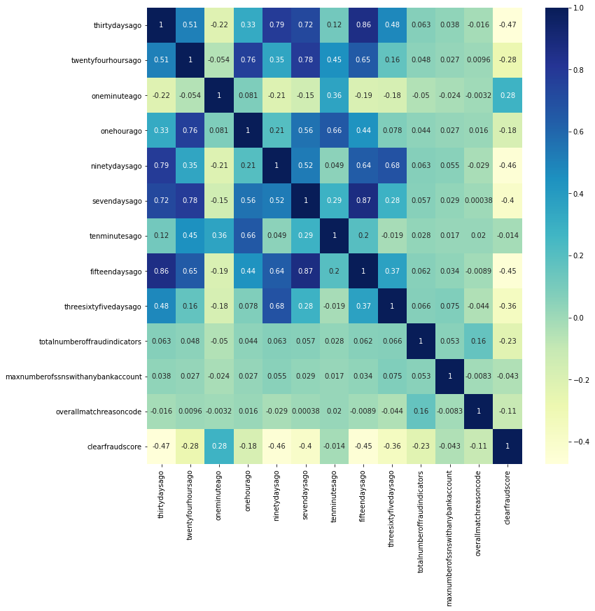

```python
# correlation map
fig, ax = plt.subplots(figsize=(12,12))
sns.heatmap(df_underwriting.corr(), cmap="YlGnBu", annot=True)
```

From the correlation map, `_days` colmuns tend to be more correlated with `_days` columns, `_hours` with `_hours` and `_minutes` with `_minutes`.

Now I have finished exploring all three datasets, and gained some insights on them. Then, I will combine them together into one dataset called `df_combined`. For this dataset, I will keep only loans that have a loan id on `df_payment` and have a valid `underwritingid` on `df_underwriting`.

```python
# combine datasets
df_combined = df_loan.merge(df_payment_clean, how='right', on='loanId').merge(df_underwriting, how='inner', left_on='clarityFraudId', right_on='underwritingid')
df_combined
```

|  | loanId | anon_ssn | payFrequency | apr | applicationDate | originated | originatedDate | nPaidOff | approved | isFunded | loanStatus | loanAmount | originallyScheduledPaymentAmount | state | leadType | leadCost | fpStatus | clarityFraudId | hasCF | paymentAmount | Status_Cancelled | Status_Checked | Status_None | Status_Pending | Status_Rejected | Status_Rejected Awaiting Retry | Status_Skipped | thirtydaysago | twentyfourhoursago | … |
| --- | --- | --- | --- | --- | --- | --- | --- | --- | --- | --- | --- | --- | --- | --- | --- | --- | --- | --- | --- | --- | --- | --- | --- | --- | --- | --- | --- | --- | --- | --- |
| 0 | LL-I-00002148 | 2b2951c8841c4737159133b21256e398 | B | 442.89 | 2014-12-03 15:36:04.144 | True | 2014-12-03 19:51:18.918 | NaN | True | 1 | External Collection | 1000.0 | 2408.88 | OH | lead | 25 | Checked | 56cdc263e4b05b76b3c77cd8 | 1 | 200.74 | 10 | 1 | 10 | 0 | 1 | 0 | 0 | 4.0 | 1.0 | … |
| 1 | LL-I-00202645 | 6d655fceaf71be89b0e0923409da4a2a | W | 478.67 | 2015-01-31 00:10:21.133 | True | 2015-02-02 18:52:53.444 | 0.0 | True | 1 | Paid Off Loan | 600.0 | 1463.49 | OH | lead | 6 | Checked | 54cc1d67e4b0ba763e445b45 | 1 | 731.23 | 21 | 4 | 0 | 0 | 0 | 0 | 0 | 5.0 | 5.0 | … |
| 2 | LL-I-00202774 | e231152748a80ccd619017d44034923f | B | 570.32 | 2015-01-31 02:07:32.590 | True | 2015-02-02 19:58:48.514 | 0.0 | True | 1 | External Collection | 400.0 | 1087.90 | OH | lead | 10 | Checked | 54cc38e1e4b0ba763e44dad0 | 1 | 106.54 | 9 | 1 | 9 | 0 | 2 | 0 | 0 | 11.0 | 6.0 | … |
| 3 | LL-I-00204105 | 4e4f9e943655df43f0b3d80f532ac7a9 | W | 478.67 | 2015-01-31 18:39:52.732 | True | 2015-02-02 15:13:53.721 | 0.0 | True | 1 | Paid Off Loan | 800.0 | 1951.32 | OH | lead | 10 | Checked | 54cd2174e4b0ba763e4b1909 | 1 | 1993.07 | 0 | 24 | 0 | 0 | 0 | 0 | 0 | 5.0 | 5.0 | … |
| 4 | LL-I-00204517 | 5907189120b48af8faabea2c7640791b | B | 478.67 | 2015-01-31 20:56:10.982 | True | 2015-02-02 17:04:57.616 | 0.0 | True | 1 | Settlement Paid Off | 700.0 | 1679.37 | OH | lead | 75 | Checked | 54cd4169e4b0ba763e4cfc18 | 1 | 1465.97 | 0 | 11 | 0 | 0 | 2 | 0 | 1 | 3.0 | 2.0 | … |
| ... | ... | ... | ... | ... | ... | ... | ... | ... | ... | ... | ... | ... | ... | ... | ... | ... | ... | ... | ... | ... | ... | ... | ... | ... | ... | ... | ... | ... | ... | … |
| 32307 | LL-I-18583844 | 53b2b896899dfa08a8e1acbd06550895 | B | 360.00 | 2017-03-17 21:29:01.891 | True | 2017-03-17 21:45:19.912 | 1.0 | True | 1 | Paid Off Loan | 1500.0 | 3394.23 | IL | organic | 0 | Checked | 58b3209ce4b0bf8053054799 | 1 | NaN | 0 | 0 | 13 | 0 | 0 | 0 | 0 | 3.0 | 3.0 | … |
| 32308 | LL-I-18611386 | 6b53e6f23d582fbbf0b2eb208c1cae57 | B | 180.20 | 2017-03-18 16:24:22.213 | True | 2017-03-18 16:30:22.639 | 2.0 | True | 1 | Internal Collection | 500.0 | 788.11 | CO | organic | 0 | Rejected | 589416afe4b08f24aa241df9 | 1 | NaN | 0 | 0 | 13 | 0 | 0 | 0 | 0 | 2.0 | 2.0 | … |
| 32309 | LL-T-01984747 | c936ad3c9b0e3ec05119e8865c317988 | W | 44.00 | 2015-07-29 12:59:06.345 | True | 2015-08-04 16:01:55.480 | 0.0 | True | 1 | External Collection | 300.0 | 335.07 | SC | bvMandatory | 6 | NaN | 55bfb151e4b0a5e80c4ef9f1 | 1 | NaN | 0 | 0 | 26 | 0 | 0 | 0 | 0 | 14.0 | 1.0 | … |
| 32310 | LP-I-00000030 | 52166b67e3d299a8a9239b31a8af9a7b | B | 29.99 | 2015-10-05 13:07:49.995 | True | 2015-10-07 12:57:25.592 | NaN | True | 1 | Paid Off Loan | 1040.0 | 1120.22 | WA | lionpay | 0 | Checked | 5615346ce4b0fcaaf03e50a1 | 1 | 1120.22 | 0 | 12 | 0 | 0 | 0 | 0 | 0 | 2.0 | 1.0 | … |
| 32311 | LP-I-00000139 | 1db95f73fc34d2e5230aa927bb11a192 | B | 29.99 | 2016-02-23 22:22:57.455 | True | 2016-02-25 14:11:05.477 | 0.0 | True | 1 | Paid Off Loan | 845.0 | 911.64 | ID | lionpay | 0 | Checked | 56cf0b28e4b05b76b4820eb1 | 1 | 910.25 | 0 | 12 | 0 | 0 | 3 | 0 | 0 | 3.0 | 1.0 | … |

32312 rows × 81 columns

Finally, I will export it to `df_combined.csv` for future usage.

```python
# export to csv
df_combined_path = 'data/data/combined.csv'
df_combined.to_csv(df_combined_path, index=False)
```

### Deeper Data Exploration

[go back to the top]

With a newly combined dataset, I will again explore further on the dataset.

```python
df_combined = pd.read_csv('data/data/combined.csv', parse_dates=["applicationDate", "originatedDate"] )

df_combined_info = df_combined.describe(include='all', datetime_is_numeric=True)

df_combined_info.loc['dtype'] = df_combined.dtypes
df_combined_info.loc['null'] = df_combined.isna().sum()
df_combined_info.loc['% null'] = df_combined.isna().mean()

df_combined_info
```

|  | loanId | anon_ssn | payFrequency | apr | applicationDate | originated | originatedDate | nPaidOff | approved | isFunded | loanStatus | loanAmount | originallyScheduledPaymentAmount | state | leadType | leadCost | fpStatus | clarityFraudId | hasCF | paymentAmount | Status_Cancelled | Status_Checked | Status_None | Status_Pending | Status_Rejected | Status_Rejected Awaiting Retry | Status_Skipped | thirtydaysago | twentyfourhoursago | … |
| --- | --- | --- | --- | --- | --- | --- | --- | --- | --- | --- | --- | --- | --- | --- | --- | --- | --- | --- | --- | --- | --- | --- | --- | --- | --- | --- | --- | --- | --- | --- |
| count | 32312 | 32312 | 32312 | 32312.0 | 32312 | 32312 | 32294 | 32310.0 | 32312 | 32312.0 | 32312 | 32312.0 | 32312.0 | 32312 | 32312 | 32312.0 | 32171 | 32312 | 32312.0 | 25917.0 | 32312.0 | 32312.0 | 32312.0 | 32312.0 | 32312.0 | 32312.0 | 32312.0 | 32311.0 | 32311.0 | … |
| unique | 32312 | 30011 | 5 | NaN | NaN | 2 | NaN | NaN | 2 | NaN | 14 | NaN | NaN | 40 | 10 | NaN | 5 | 30690 | NaN | NaN | NaN | NaN | NaN | NaN | NaN | NaN | NaN | NaN | NaN | … |
| top | LL-I-00002148 | 228060b9cc8af6a937d0321122d459f3 | B | NaN | NaN | True | NaN | NaN | True | NaN | External Collection | NaN | NaN | OH | bvMandatory | NaN | Checked | 55a92c0be4b09db1ea9bc94c | NaN | NaN | NaN | NaN | NaN | NaN | NaN | NaN | NaN | NaN | NaN | … |
| freq | 1 | 10 | 18759 | NaN | NaN | 32294 | NaN | NaN | 32294 | NaN | 9335 | NaN | NaN | 5017 | 14625 | NaN | 27049 | 6 | NaN | NaN | NaN | NaN | NaN | NaN | NaN | NaN | NaN | NaN | NaN | … |
| mean | NaN | NaN | NaN | 532.525995 | 2016-08-07 20:56:18.741624064 | NaN | 2016-08-08 18:59:17.811927296 | 0.170659 | NaN | 0.995791 | NaN | 656.350752 | 1804.872223 | NaN | NaN | 13.81332 | NaN | NaN | 1.0 | 766.969594 | 6.744522 | 5.283022 | 4.088512 | 0.231462 | 0.840709 | 0.000464 | 0.090524 | 7.369843 | 4.62799 | … |
| min | NaN | NaN | NaN | 29.99 | 2014-12-03 15:36:04.144000 | NaN | 2014-12-03 19:51:18.918000 | 0.0 | NaN | 0.0 | NaN | 100.0 | 188.41 | NaN | NaN | 0.0 | NaN | NaN | 1.0 | 0.01 | 0.0 | 0.0 | 0.0 | 0.0 | 0.0 | 0.0 | 0.0 | 0.0 | 0.0 | … |
| 25% | NaN | NaN | NaN | 449.0 | 2016-03-03 04:48:16.159749888 | NaN | 2016-03-04 17:23:09.025250048 | 0.0 | NaN | 1.0 | NaN | 400.0 | 1073.56 | NaN | NaN | 3.0 | NaN | NaN | 1.0 | 259.02 | 0.0 | 1.0 | 0.0 | 0.0 | 0.0 | 0.0 | 0.0 | 3.0 | 3.0 | … |
| 50% | NaN | NaN | NaN | 590.0 | 2016-11-10 22:56:05.862000128 | NaN | 2016-11-12 19:45:31.500000 | 0.0 | NaN | 1.0 | NaN | 500.0 | 1406.345 | NaN | NaN | 6.0 | NaN | NaN | 1.0 | 558.66 | 4.0 | 3.0 | 0.0 | 0.0 | 0.0 | 0.0 | 0.0 | 5.0 | 3.0 | … |
| 75% | NaN | NaN | NaN | 645.0 | 2017-01-12 18:53:00.525750016 | NaN | 2017-01-12 21:53:54.970749952 | 0.0 | NaN | 1.0 | NaN | 700.0 | 2025.985 | NaN | NaN | 25.0 | NaN | NaN | 1.0 | 1008.46 | 11.0 | 8.0 | 8.0 | 0.0 | 2.0 | 0.0 | 0.0 | 9.0 | 5.0 | … |
| max | NaN | NaN | NaN | 681.0 | 2017-03-18 23:34:27.369000 | NaN | 2017-03-19 00:15:16.291000 | 20.0 | NaN | 1.0 | NaN | 4687.0 | 16868.15 | NaN | NaN | 200.0 | NaN | NaN | 1.0 | 8556.58 | 104.0 | 48.0 | 104.0 | 3.0 | 18.0 | 2.0 | 9.0 | 89.0 | 60.0 | … |
| std | NaN | NaN | NaN | 128.612733 | NaN | NaN | NaN | 0.599064 | NaN | 0.064741 | NaN | 495.834743 | 1311.878831 | NaN | NaN | 21.429333 | NaN | NaN | 0.0 | 764.225916 | 8.129062 | 6.043304 | 6.692462 | 0.477785 | 1.098886 | 0.022933 | 0.318622 | 6.471618 | 3.375776 | … |
| dtype | object | object | object | float64 | datetime64[ns] | bool | datetime64[ns] | float64 | bool | int64 | object | float64 | float64 | object | object | int64 | object | object | int64 | float64 | int64 | int64 | int64 | int64 | int64 | int64 | int64 | float64 | float64 | … |
| null | 0 | 0 | 0 | 0 | 0 | 0 | 18 | 2 | 0 | 0 | 0 | 0 | 0 | 0 | 0 | 0 | 141 | 0 | 0 | 6395 | 0 | 0 | 0 | 0 | 0 | 0 | 0 | 1 | 1 | … |
| % null | 0.0 | 0.0 | 0.0 | 0.0 | 0.0 | 0.0 | 0.000557 | 0.000062 | 0.0 | 0.0 | 0.0 | 0.0 | 0.0 | 0.0 | 0.0 | 0.0 | 0.004364 | 0.0 | 0.0 | 0.197914 | 0.0 | 0.0 | 0.0 | 0.0 | 0.0 | 0.0 | 0.0 | 0.000031 | 0.000031 | … |

From the information above, possible column that can be used as a standard to define **`quality loan`** or **`risky loan`** will be `loanStatus` as the it represents the current loan status. So, it's a good option to define `loanStatus` as our label (y). Therefore, it's crucial to further look into the data within it so that we can well-defined **quality vs risky loan** status.

```python
df_combined.loanStatus.value_counts(normalize=True)
```

```
External Collection         0.288902
Paid Off Loan               0.281196
New Loan                    0.202061
Internal Collection         0.158888
Returned Item               0.032527
Settlement Paid Off         0.016588
Settled Bankruptcy          0.008758
Pending Paid Off            0.003466
Charged Off Paid Off        0.003373
Credit Return Void          0.002166
Customer Voided New Loan    0.001455
CSR Voided New Loan         0.000495
Withdrawn Application       0.000093
Charged Off                 0.000031
Name: loanStatus, dtype: float64
```

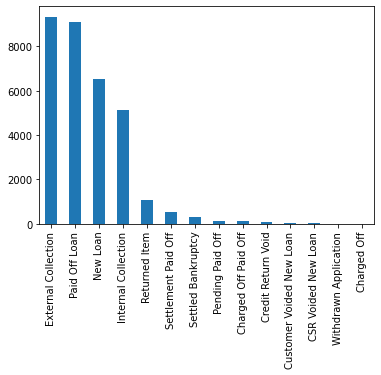

```python
df_combined.loanStatus.value_counts().plot.bar()
```

From the data, I will combine several columns as they convey similar meaning.

- Definition of [void loan](https://userguide.nortridge.com/topics/voiding-a-loan.html#:~:text=When%20a%20loan%20is%20voided,reported%20to%20a%20credit%20bureau.)
- Defintion of [collection](https://www.experian.com/blogs/ask-experian/credit-education/report-basics/how-and-when-collections-are-removed-from-a-credit-report/) (both external and internal)

| Old data | New data |
| --- | --- |
| `Credit Return Void`,`Customer Voided New Loan`, `CSR Voided New Loan` | `Customer Voided New Loan` |
| `Paid Off Loan`,`Settlement Paid Off` | `Loan Paid Off` |

```python
condition1 = (df_combined.loanStatus == 'Credit Return Void') | (df_combined.loanStatus == 'Customer Voided New Loan') | (df_combined.loanStatus == 'CSR Voided New Loan')
condition2 = (df_combined.loanStatus == 'Paid Off Loan') | (df_combined.loanStatus == 'Settlement Paid Off')

df_combined.loc[condition1, 'loanStatus'] = 'Customer Voided New Loan'
df_combined.loc[condition2, 'loanStatus'] = 'Loan Paid Off'
```

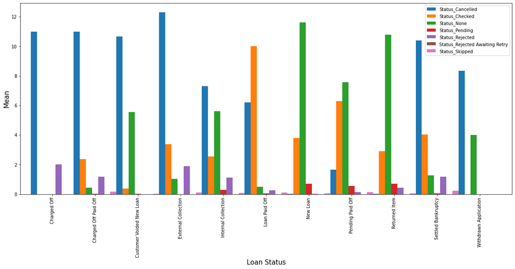

```python
columns = ['Status_Cancelled','Status_Checked','Status_None','Status_Pending','Status_Rejected','Status_Rejected Awaiting Retry','Status_Skipped']
df_loan_status = df_combined.groupby('loanStatus')[columns].mean()

ax = df_loan_status.plot(kind='bar', figsize=(20,8), width = 1);
ax.set_alpha(0.8)
ax.set_xlabel("Loan Status", fontsize=15);
ax.set_ylabel("Mean", fontsize=15);
plt.show()
```

From the graph above and the definition of the loan status, it's easier to determine a loan is `risky` or not.

| Risky | Loan Status |
| --- | --- |
| 0 | `Loan Paid Off`,`New Loan`,`Pending Paid Off`,`Returned Item` |
| 1 | `Charged Off`,`Charged Off Paid Off`,`External Collection`,`Internal Collection`,`Settled Bankruptcy` |

I didn't include `Customer Voided New Loan` and `Withdrawn Application` as it's hard to define them as risky or non-risky (There's a lot of reason that leads to both categories).

```python
# dictionary that define risky loan from loan status calumn
risky_category = {
    "Loan Paid Off": 0,
    "New Loan": 0,
    "Pending Paid Off": 0,
    "Returned Item": 0,
    "Charged Off": 1,
    "Charged Off Paid Off": 1,
    "External Collection": 1,
    "Internal Collection": 1,
    "Settled Bankruptcy": 1
}

df_combined['isRisky'] = df_combined.loanStatus.map(risky_category)
df_combined = df_combined[df_combined.isRisky.notna()]
df_combined.isRisky.value_counts(normalize=True)
```

```
0.0    0.538103
1.0    0.461897
Name: isRisky, dtype: float64
```

This results a balanced dataset as there is only $7\%$ differences between class `0` (non-risky) and class `1` (risky).

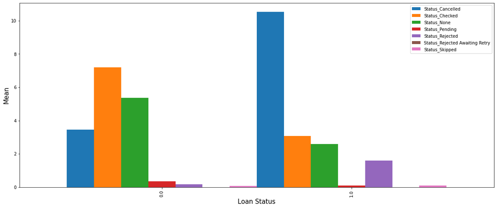

```python
columns = ['Status_Cancelled','Status_Checked','Status_None','Status_Pending','Status_Rejected','Status_Rejected Awaiting Retry','Status_Skipped']
df_loan_status = df_combined.groupby('isRisky')[columns].mean()

ax = df_loan_status.plot(kind='bar', figsize=(20,8), width = 1);
ax.set_alpha(0.8)
ax.set_xlabel("Loan Status", fontsize=15);
ax.set_ylabel("Mean", fontsize=15);
plt.show()
```

From the graph above, `risky` loan have higher **`Cancelled`** and **`Rejected`** status while `non-risky` (or `quality`) loan have higher **`None`** and **`Checked`** status.

```python
df_combined_info = df_combined.describe(include='all', datetime_is_numeric=True)

df_combined_info.loc['dtype'] = df_combined.dtypes
df_combined_info.loc['null'] = df_combined.isna().sum()
df_combined_info.loc['% null'] = df_combined.isna().mean()

df_combined_info
```

|  | loanId | anon_ssn | payFrequency | apr | applicationDate | originated | originatedDate | nPaidOff | approved | isFunded | loanStatus | loanAmount | originallyScheduledPaymentAmount | state | leadType | leadCost | fpStatus | clarityFraudId | hasCF | paymentAmount | Status_Cancelled | Status_Checked | Status_None | Status_Pending | Status_Rejected | Status_Rejected Awaiting Retry | Status_Skipped | thirtydaysago | twentyfourhoursago | … |
| --- | --- | --- | --- | --- | --- | --- | --- | --- | --- | --- | --- | --- | --- | --- | --- | --- | --- | --- | --- | --- | --- | --- | --- | --- | --- | --- | --- | --- | --- | --- |
| count | 32176 | 32176 | 32176 | 32176.0 | 32176 | 32176 | 32176 | 32174.0 | 32176 | 32176.0 | 32176 | 32176.0 | 32176.0 | 32176 | 32176 | 32176.0 | 32171 | 32176 | 32176.0 | 25871.0 | 32176.0 | 32176.0 | 32176.0 | 32176.0 | 32176.0 | 32176.0 | 32176.0 | 32175.0 | 32175.0 | … |
| unique | 32176 | 29934 | 5 | NaN | NaN | 1 | NaN | NaN | 1 | NaN | 9 | NaN | NaN | 40 | 10 | NaN | 5 | 30611 | NaN | NaN | NaN | NaN | NaN | NaN | NaN | NaN | NaN | NaN | NaN | … |
| top | LL-I-00002148 | 228060b9cc8af6a937d0321122d459f3 | B | NaN | NaN | True | NaN | NaN | True | NaN | Loan Paid Off | NaN | NaN | OH | bvMandatory | NaN | Checked | 55a92c0be4b09db1ea9bc94c | NaN | NaN | NaN | NaN | NaN | NaN | NaN | NaN | NaN | NaN | NaN | … |
| freq | 1 | 10 | 18679 | NaN | NaN | 32176 | NaN | NaN | 32176 | NaN | 9622 | NaN | NaN | 5000 | 14601 | NaN | 27049 | 6 | NaN | NaN | NaN | NaN | NaN | NaN | NaN | NaN | NaN | NaN | NaN | … |
| mean | NaN | NaN | NaN | 532.511221 | 2016-08-07 18:37:32.324655872 | NaN | 2016-08-08 19:37:22.741466112 | 0.1702 | NaN | 1.0 | NaN | 656.169769 | 1804.346363 | NaN | NaN | 13.787668 | NaN | NaN | 1.0 | 767.079301 | 6.728245 | 5.303767 | 4.082484 | 0.232378 | 0.844263 | 0.000466 | 0.090844 | 7.374079 | 4.629464 | … |
| min | NaN | NaN | NaN | 29.99 | 2014-12-03 15:36:04.144000 | NaN | 2014-12-03 19:51:18.918000 | 0.0 | NaN | 1.0 | NaN | 100.0 | 188.41 | NaN | NaN | 0.0 | NaN | NaN | 1.0 | 0.01 | 0.0 | 0.0 | 0.0 | 0.0 | 0.0 | 0.0 | 0.0 | 0.0 | 0.0 | … |
| 25% | NaN | NaN | NaN | 449.0 | 2016-03-03 04:23:05.790749952 | NaN | 2016-03-04 19:23:36.981499904 | 0.0 | NaN | 1.0 | NaN | 400.0 | 1073.56 | NaN | NaN | 3.0 | NaN | NaN | 1.0 | 258.805 | 0.0 | 1.0 | 0.0 | 0.0 | 0.0 | 0.0 | 0.0 | 3.0 | 3.0 | … |
| 50% | NaN | NaN | NaN | 590.0 | 2016-11-10 22:39:25.517999872 | NaN | 2016-11-13 14:16:49.216000 | 0.0 | NaN | 1.0 | NaN | 500.0 | 1405.485 | NaN | NaN | 6.0 | NaN | NaN | 1.0 | 558.45 | 4.0 | 3.0 | 0.0 | 0.0 | 0.0 | 0.0 | 0.0 | 5.0 | 3.0 | … |
| 75% | NaN | NaN | NaN | 645.0 | 2017-01-12 17:11:03.946249984 | NaN | 2017-01-12 20:57:40.532000 | 0.0 | NaN | 1.0 | NaN | 700.0 | 2023.76 | NaN | NaN | 25.0 | NaN | NaN | 1.0 | 1009.1 | 11.0 | 8.0 | 8.0 | 0.0 | 2.0 | 0.0 | 0.0 | 9.0 | 5.0 | … |
| max | NaN | NaN | NaN | 681.0 | 2017-03-18 23:34:27.369000 | NaN | 2017-03-19 00:15:16.291000 | 20.0 | NaN | 1.0 | NaN | 4687.0 | 16868.15 | NaN | NaN | 200.0 | NaN | NaN | 1.0 | 8556.58 | 104.0 | 48.0 | 104.0 | 3.0 | 18.0 | 2.0 | 9.0 | 89.0 | 60.0 | … |
| std | NaN | NaN | NaN | 128.615829 | NaN | NaN | NaN | 0.598436 | NaN | 0.0 | NaN | 496.075899 | 1312.545724 | NaN | NaN | 21.433567 | NaN | NaN | 0.0 | 764.548978 | 8.115881 | 6.047491 | 6.688261 | 0.478521 | 1.099842 | 0.022981 | 0.319161 | 6.47394 | 3.377902 | … |
| dtype | object | object | object | float64 | datetime64[ns] | bool | datetime64[ns] | float64 | bool | int64 | object | float64 | float64 | object | object | int64 | object | object | int64 | float64 | int64 | int64 | int64 | int64 | int64 | int64 | int64 | float64 | float64 | … |
| null | 0 | 0 | 0 | 0 | 0 | 0 | 0 | 2 | 0 | 0 | 0 | 0 | 0 | 0 | 0 | 0 | 5 | 0 | 0 | 6305 | 0 | 0 | 0 | 0 | 0 | 0 | 0 | 1 | 1 | … |
| % null | 0.0 | 0.0 | 0.0 | 0.0 | 0.0 | 0.0 | 0.0 | 0.000062 | 0.0 | 0.0 | 0.0 | 0.0 | 0.0 | 0.0 | 0.0 | 0.0 | 0.000155 | 0.0 | 0.0 | 0.195954 | 0.0 | 0.0 | 0.0 | 0.0 | 0.0 | 0.0 | 0.0 | 0.000031 | 0.000031 | … |

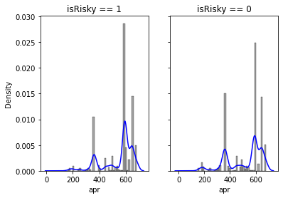

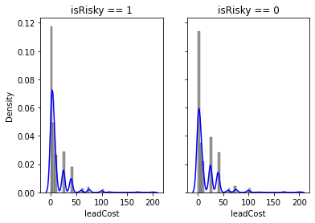

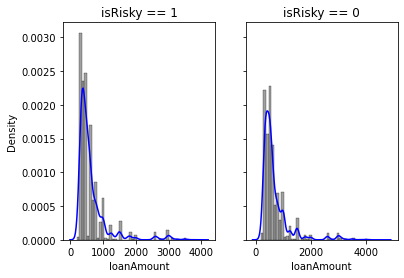

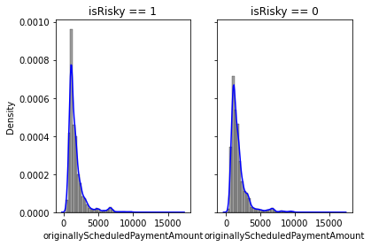

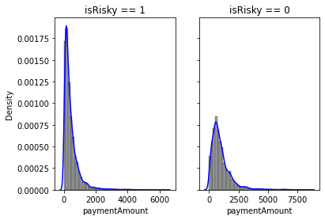

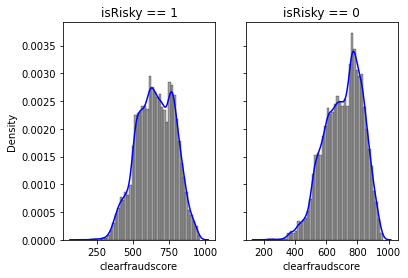

```python
numeric_columns = ['apr', 'leadCost', 'loanAmount','originallyScheduledPaymentAmount','paymentAmount','clearfraudscore']

df_risky = df_combined[df_combined.isRisky == 1]
df_non_risky = df_combined[df_combined.isRisky == 0]

for col in numeric_columns:
    fig, (ax1, ax2) = plt.subplots(1, 2, sharey=True)

#     plot graphs for numeric columns (one with risky status and another with non-risky status)
    sns.histplot(df_risky[col], ax=ax1, stat='density', bins = 50, color='gray')
    sns.kdeplot(df_risky[col], ax=ax1, color='b')
    ax1.set_title('isRisky == 1')
    sns.histplot(df_non_risky[col], ax=ax2, stat='density', bins = 50, color='gray')
    sns.kdeplot(df_non_risky[col], ax=ax2, color='b')
    ax2.set_title('isRisky == 0')
    plt.show()
```

From the graph above

- It is hard to differentiate between `risky` and `non-risky` loans as their curves are similar
- `apr` and `leadCost` looks like a [multimodal distrbution](https://www.statology.org/multimodal-distribution/) with different peaks.
- `loanAmount`, `originallyScheduledPaymentAmount` and `paymentAmount` are positively skewed (skewed to the right)
- `clearfraudscore` is approximately a normal distribution

### Feature Engineering

[go back to the top]

In this part, I will handle missing values, perform data cleaning, feature selection and feature creation.

First, I will figure out columns where missing values are more than $30\%$ and drop these columns (Imagine we have to impute $30\%$ of the missing values and these may largely affects the model performances).

```python
# check the percentage of missing values in each columns with descending order
df_combined.isna().mean().sort_values(ascending=False).head(20)
```

```
phonetype                                    0.968828
ssnnamereasoncodedescription                 0.945332
ssnnamereasoncode                            0.945332
nameaddressreasoncodedescription             0.888084
nameaddressreasoncode                        0.888084
ssndobreasoncode                             0.819058
driverlicenseinconsistentwithonfile          0.802430
workphonepreviouslylistedascellphone         0.540807
workphonepreviouslylistedashomephone         0.540807
paymentAmount                                0.195954
driverlicenseformatinvalid                   0.105700
phonematchtypedescription                    0.018958
phonematchtype                               0.018958
telephonenumberinconsistentwithstate         0.013923
clearfraudscore                              0.002859
onfileaddresshighrisk                        0.001057
bestonfilessnrecordedasdeceased              0.001057
ssnreportedmorefrequentlyforanother          0.001057
onfileaddresscautious                        0.001057
currentaddressreportedbytradeopenlt90days    0.001057
dtype: float64
```

```python
# remove columns where missing value > 30% of the column
df_combined = df_combined.loc[:, df_combined.isna().mean() < 0.3]
df_combined.shape
```

```
(32176, 73)
```

```python
df_combined_info = df_combined.describe(include='all', datetime_is_numeric=True)

df_combined_info.loc['dtype'] = df_combined.dtypes
df_combined_info.loc['null'] = df_combined.isna().sum()
df_combined_info.loc['% null'] = df_combined.isna().mean()

df_combined_info
```

|  | loanId | anon_ssn | payFrequency | apr | applicationDate | originated | originatedDate | nPaidOff | approved | isFunded | loanStatus | loanAmount | originallyScheduledPaymentAmount | state | leadType | leadCost | fpStatus | clarityFraudId | hasCF | paymentAmount | Status_Cancelled | Status_Checked | Status_None | Status_Pending | Status_Rejected | Status_Rejected Awaiting Retry | Status_Skipped | thirtydaysago | twentyfourhoursago | … |
| --- | --- | --- | --- | --- | --- | --- | --- | --- | --- | --- | --- | --- | --- | --- | --- | --- | --- | --- | --- | --- | --- | --- | --- | --- | --- | --- | --- | --- | --- | --- |
| count | 32176 | 32176 | 32176 | 32176.0 | 32176 | 32176 | 32176 | 32174.0 | 32176 | 32176.0 | 32176 | 32176.0 | 32176.0 | 32176 | 32176 | 32176.0 | 32171 | 32176 | 32176.0 | 25871.0 | 32176.0 | 32176.0 | 32176.0 | 32176.0 | 32176.0 | 32176.0 | 32176.0 | 32175.0 | 32175.0 | … |
| unique | 32176 | 29934 | 5 | NaN | NaN | 1 | NaN | NaN | 1 | NaN | 9 | NaN | NaN | 40 | 10 | NaN | 5 | 30611 | NaN | NaN | NaN | NaN | NaN | NaN | NaN | NaN | NaN | NaN | NaN | … |
| top | LL-I-00002148 | 228060b9cc8af6a937d0321122d459f3 | B | NaN | NaN | True | NaN | NaN | True | NaN | Loan Paid Off | NaN | NaN | OH | bvMandatory | NaN | Checked | 55a92c0be4b09db1ea9bc94c | NaN | NaN | NaN | NaN | NaN | NaN | NaN | NaN | NaN | NaN | NaN | … |
| freq | 1 | 10 | 18679 | NaN | NaN | 32176 | NaN | NaN | 32176 | NaN | 9622 | NaN | NaN | 5000 | 14601 | NaN | 27049 | 6 | NaN | NaN | NaN | NaN | NaN | NaN | NaN | NaN | NaN | NaN | NaN | … |
| mean | NaN | NaN | NaN | 532.511221 | 2016-08-07 18:37:32.324655872 | NaN | 2016-08-08 19:37:22.741466112 | 0.1702 | NaN | 1.0 | NaN | 656.169769 | 1804.346363 | NaN | NaN | 13.787668 | NaN | NaN | 1.0 | 767.079301 | 6.728245 | 5.303767 | 4.082484 | 0.232378 | 0.844263 | 0.000466 | 0.090844 | 7.374079 | 4.629464 | … |
| min | NaN | NaN | NaN | 29.99 | 2014-12-03 15:36:04.144000 | NaN | 2014-12-03 19:51:18.918000 | 0.0 | NaN | 1.0 | NaN | 100.0 | 188.41 | NaN | NaN | 0.0 | NaN | NaN | 1.0 | 0.01 | 0.0 | 0.0 | 0.0 | 0.0 | 0.0 | 0.0 | 0.0 | 0.0 | 0.0 | … |
| 25% | NaN | NaN | NaN | 449.0 | 2016-03-03 04:23:05.790749952 | NaN | 2016-03-04 19:23:36.981499904 | 0.0 | NaN | 1.0 | NaN | 400.0 | 1073.56 | NaN | NaN | 3.0 | NaN | NaN | 1.0 | 258.805 | 0.0 | 1.0 | 0.0 | 0.0 | 0.0 | 0.0 | 0.0 | 3.0 | 3.0 | … |
| 50% | NaN | NaN | NaN | 590.0 | 2016-11-10 22:39:25.517999872 | NaN | 2016-11-13 14:16:49.216000 | 0.0 | NaN | 1.0 | NaN | 500.0 | 1405.485 | NaN | NaN | 6.0 | NaN | NaN | 1.0 | 558.45 | 4.0 | 3.0 | 0.0 | 0.0 | 0.0 | 0.0 | 0.0 | 5.0 | 3.0 | … |
| 75% | NaN | NaN | NaN | 645.0 | 2017-01-12 17:11:03.946249984 | NaN | 2017-01-12 20:57:40.532000 | 0.0 | NaN | 1.0 | NaN | 700.0 | 2023.76 | NaN | NaN | 25.0 | NaN | NaN | 1.0 | 1009.1 | 11.0 | 8.0 | 8.0 | 0.0 | 2.0 | 0.0 | 0.0 | 9.0 | 5.0 | … |
| max | NaN | NaN | NaN | 681.0 | 2017-03-18 23:34:27.369000 | NaN | 2017-03-19 00:15:16.291000 | 20.0 | NaN | 1.0 | NaN | 4687.0 | 16868.15 | NaN | NaN | 200.0 | NaN | NaN | 1.0 | 8556.58 | 104.0 | 48.0 | 104.0 | 3.0 | 18.0 | 2.0 | 9.0 | 89.0 | 60.0 | … |
| std | NaN | NaN | NaN | 128.615829 | NaN | NaN | NaN | 0.598436 | NaN | 0.0 | NaN | 496.075899 | 1312.545724 | NaN | NaN | 21.433567 | NaN | NaN | 0.0 | 764.548978 | 8.115881 | 6.047491 | 6.688261 | 0.478521 | 1.099842 | 0.022981 | 0.319161 | 6.47394 | 3.377902 | … |
| dtype | object | object | object | float64 | datetime64[ns] | bool | datetime64[ns] | float64 | bool | int64 | object | float64 | float64 | object | object | int64 | object | object | int64 | float64 | int64 | int64 | int64 | int64 | int64 | int64 | int64 | float64 | float64 | … |
| null | 0 | 0 | 0 | 0 | 0 | 0 | 0 | 2 | 0 | 0 | 0 | 0 | 0 | 0 | 0 | 0 | 5 | 0 | 0 | 6305 | 0 | 0 | 0 | 0 | 0 | 0 | 0 | 1 | 1 | … |
| % null | 0.0 | 0.0 | 0.0 | 0.0 | 0.0 | 0.0 | 0.0 | 0.000062 | 0.0 | 0.0 | 0.0 | 0.0 | 0.0 | 0.0 | 0.0 | 0.0 | 0.000155 | 0.0 | 0.0 | 0.195954 | 0.0 | 0.0 | 0.0 | 0.0 | 0.0 | 0.0 | 0.0 | 0.000031 | 0.000031 | … |

Still, there's 73 columns left inside the dataset. In this case, I will manually search for columns that is unnecessary for the model building.

| Column | Reason |
| --- | --- |
| **`loanId`** | `Unique ID to join between dataset` |
| **`applicationDate`** | `Datetime user applied for the loan` |
| **`originated`** | `All loans are originated, contains only one unique value` |
| **`originatedDate`** | `Datetime loan is originated` |
| **`approved`** | `All loans are approved, contains only one unique value` |
| **`isFunded`** | `All loans are funded, contains only one unique value` |
| **`loanStatus`** | `Column used to define label`**`isRisky`** |
| **`clarityFraudId`** | `Unique ID to join between dataset` |
| **`hasCF`** | `All loans have copywriting fraud ID, contains only one unique value` |
| **`underwritingid`** | `Unique ID to join between dataset` |
| **`inputssninvalid`** | `Contains only one unique value` |
| **`inputssnrecordedasdeceased`** | `Contains only one unique value` |
| **`bestonfilessnissuedatecannotbeverified`** | `Contains only one unique value` |
| **`bestonfilessnrecordedasdeceased`** | `Contains only one unique value` |
| **`phonematchtype`** | `Duplicated columns with`**`phonematchtypedescription`** |

```python
drop_columns = ['loanId','applicationDate','originated','originatedDate','approved','isFunded','loanStatus','clarityFraudId','hasCF','underwritingid','inputssninvalid', 'inputssnrecordedasdeceased', 'bestonfilessnissuedatecannotbeverified', 'bestonfilessnrecordedasdeceased', 'phonematchtype']
df_combined.drop(columns = drop_columns, inplace=True)
df_combined.shape
```

```
(32176, 58)
```

Next, I will work on missing values.

`paymentAmount` is null because the loan is not pay yet, so I will fill it manually by **0**

```python
df_combined.paymentAmount.fillna(0, inplace=True)
```

`clearfraudscore` is null because other columns in calculating `clearfraudscore` contains null values, so I will **drop** these rows.

```python
old_shape = df_combined.shape[0]
na_num = df_combined.clearfraudscore.isna().sum()
df_combined.dropna(subset=['clearfraudscore'], inplace=True)

old_shape, df_combined.shape[0], na_num, old_shape - df_combined.shape[0]
```

```
(32176, 32084, 92, 92)
```

```python
df_combined.isna().mean().sort_values(ascending=False).head(10)
```

```
driverlicenseformatinvalid              0.105068
phonematchtypedescription               0.017953
telephonenumberinconsistentwithstate    0.013433
fpStatus                                0.000156
nPaidOff                                0.000062
anon_ssn                                0.000000
inquiryaddresscautious                  0.000000
creditestablishedpriortossnissuedate    0.000000
onfileaddressnonresidential             0.000000
morethan3inquiriesinthelast30days       0.000000
dtype: float64
```

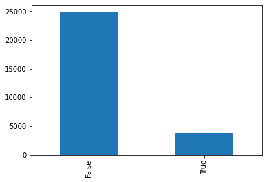

```python
# plot driverlicenseformatinvalid
df_combined.driverlicenseformatinvalid.value_counts().plot.bar()
```

Based on the graph, I will fill null values with **False** (mode)

```python
df_combined.loc[df_combined.driverlicenseformatinvalid.isna(), 'driverlicenseformatinvalid'] = False
```

```python
old_shape = df_combined.shape[0]
na_num = df_combined.phonematchtypedescription.isna().sum()
df_combined.dropna(subset=['phonematchtypedescription'], inplace=True)

old_shape, df_combined.shape[0], na_num, old_shape - df_combined.shape[0]
```

```
(32084, 31508, 576, 576)
```

For the remaining three columns, I will manually look into these rows and fill in null values manually.

- For `fpStatus`, fill with **None** as no payment has been made yet. (All of the status are in None)
- For `telephonenumberinconsistentwithstate`, fill with **False** (mode)
- For `nPaidOff`, fill with **0** (mode)

```python
df_combined.loc[df_combined.fpStatus.isna()|df_combined.telephonenumberinconsistentwithstate.isna()|df_combined.nPaidOff.isna()]
```

|  | anon_ssn | payFrequency | apr | nPaidOff | loanAmount | originallyScheduledPaymentAmount | state | leadType | leadCost | fpStatus | paymentAmount | Status_Cancelled | Status_Checked | Status_None | Status_Pending | Status_Rejected | Status_Rejected Awaiting Retry | Status_Skipped | thirtydaysago | twentyfourhoursago | oneminuteago | onehourago | ninetydaysago | sevendaysago | tenminutesago | fifteendaysago | threesixtyfivedaysago | inquiryonfilecurrentaddressconflict | totalnumberoffraudindicators | … |
| --- | --- | --- | --- | --- | --- | --- | --- | --- | --- | --- | --- | --- | --- | --- | --- | --- | --- | --- | --- | --- | --- | --- | --- | --- | --- | --- | --- | --- | --- | --- |
| 0 | 2b2951c8841c4737159133b21256e398 | B | 442.89 | NaN | 1000.0 | 2408.88 | OH | lead | 25 | Checked | 200.74 | 10 | 1 | 10 | 0 | 1 | 0 | 0 | 4.0 | 1.0 | 1.0 | 1.0 | 5.0 | 1.0 | 1.0 | 1.0 | 61.0 | False | 4.0 | … |
| 1318 | 1445c29fb63bd7748d355e7bcf7e9065 | M | 590.00 | 0.0 | 325.0 | 988.64 | MO | organic | 0 | NaN | 0.00 | 0 | 0 | 6 | 0 | 0 | 0 | 0 | 8.0 | 3.0 | 1.0 | 3.0 | 8.0 | 3.0 | 3.0 | 8.0 | 26.0 | False | 1.0 | … |
| 2568 | b5d08f28ca47c338e49679dcdaec4ee7 | B | 449.99 | 0.0 | 350.0 | 641.37 | WI | bvMandatory | 3 | NaN | 0.00 | 0 | 0 | 12 | 0 | 0 | 0 | 0 | 5.0 | 1.0 | 1.0 | 1.0 | 9.0 | 5.0 | 1.0 | 5.0 | 9.0 | False | 0.0 | … |
| 2753 | 7438bde9daa5ba70d76f1f852713fe89 | B | 360.00 | 0.0 | 325.0 | 694.42 | IL | bvMandatory | 6 | NaN | 0.00 | 0 | 0 | 12 | 0 | 0 | 0 | 0 | 26.0 | 2.0 | 1.0 | 1.0 | 26.0 | 6.0 | 1.0 | 6.0 | 48.0 | False | 1.0 | … |
| 3433 | f6297c1296147c0d767181b8aeaeecac | I | 360.00 | 0.0 | 700.0 | 1508.20 | IL | lead | 100 | NaN | 0.00 | 0 | 0 | 12 | 0 | 0 | 0 | 0 | 6.0 | 6.0 | 5.0 | 6.0 | 8.0 | 6.0 | 5.0 | 6.0 | 8.0 | False | 1.0 | … |
| 5517 | 1437d6a1c28f77c960b96633618d1878 | M | 390.00 | 1.0 | 1000.0 | 1882.18 | TX | organic | 0 | Checked | 1882.18 | 0 | 6 | 0 | 0 | 0 | 0 | 0 | 6.0 | 3.0 | 3.0 | 3.0 | 11.0 | 6.0 | 3.0 | 6.0 | 18.0 | False | 5.0 | … |
| 6315 | 0dc685eae8ef0c2d8289a73e5697221e | B | 681.00 | 0.0 | 300.0 | 928.13 | OH | bvMandatory | 6 | Checked | 386.70 | 6 | 5 | 0 | 0 | 1 | 0 | 0 | 4.0 | 4.0 | 1.0 | 4.0 | 4.0 | 4.0 | 4.0 | 4.0 | 4.0 | True | 3.0 | … |
| 7809 | e55190fb5b8ce931ae4128b6449f8712 | W | 590.00 | 0.0 | 700.0 | 2081.47 | OH | prescreen | 0 | Checked | 1145.08 | 19 | 6 | 0 | 0 | 0 | 0 | 0 | 5.0 | 4.0 | 4.0 | 4.0 | 5.0 | 4.0 | 4.0 | 4.0 | 8.0 | False | 1.0 | … |
| 11102 | b455504431b92249a343f3511a2cb227 | W | 490.00 | 0.0 | 400.0 | 1104.83 | MO | bvMandatory | 3 | Rejected | 0.00 | 24 | 0 | 0 | 0 | 2 | 0 | 0 | 13.0 | 13.0 | 1.0 | 3.0 | 13.0 | 13.0 | 1.0 | 13.0 | 13.0 | False | 1.0 | … |
| 32309 | c936ad3c9b0e3ec05119e8865c317988 | W | 44.00 | 0.0 | 300.0 | 335.07 | SC | bvMandatory | 6 | NaN | 0.00 | 0 | 0 | 26 | 0 | 0 | 0 | 0 | 14.0 | 1.0 | 1.0 | 1.0 | 14.0 | 14.0 | 1.0 | 14.0 | 14.0 | True | 3.0 | … |
| 32310 | 52166b67e3d299a8a9239b31a8af9a7b | B | 29.99 | NaN | 1040.0 | 1120.22 | WA | lionpay | 0 | Checked | 1120.22 | 0 | 12 | 0 | 0 | 0 | 0 | 0 | 2.0 | 1.0 | 1.0 | 1.0 | 2.0 | 2.0 | 1.0 | 2.0 | 3.0 | False | 1.0 | … |

```python
df_combined.loc[df_combined.fpStatus.isna(), 'fpStatus'] = 'None'
df_combined.loc[df_combined.telephonenumberinconsistentwithstate.isna(), 'telephonenumberinconsistentwithstate'] = False
df_combined.loc[df_combined.nPaidOff.isna(), 'nPaidOff'] = 0
```

```python
df_combined.isna().mean().sort_values(ascending=False).head(3)
```

```
anon_ssn                          0.0
inquirycurrentaddressnotonfile    0.0
onfileaddresscautious             0.0
dtype: float64
```

Cool! There's no more missing values in the dataset.

```python
df_combined_info = df_combined.describe(include='all')
df_combined_info.loc['dtype'] = df_combined.dtypes
df_combined_info
```

|  | anon_ssn | payFrequency | apr | nPaidOff | loanAmount | originallyScheduledPaymentAmount | state | leadType | leadCost | fpStatus | paymentAmount | Status_Cancelled | Status_Checked | Status_None | Status_Pending | Status_Rejected | Status_Rejected Awaiting Retry | Status_Skipped | thirtydaysago | twentyfourhoursago | oneminuteago | onehourago | ninetydaysago | sevendaysago | tenminutesago | fifteendaysago | threesixtyfivedaysago | inquiryonfilecurrentaddressconflict | totalnumberoffraudindicators | … |
| --- | --- | --- | --- | --- | --- | --- | --- | --- | --- | --- | --- | --- | --- | --- | --- | --- | --- | --- | --- | --- | --- | --- | --- | --- | --- | --- | --- | --- | --- | --- |
| count | 31508 | 31508 | 31508.0 | 31508.0 | 31508.0 | 31508.0 | 31508 | 31508 | 31508.0 | 31508 | 31508.0 | 31508.0 | 31508.0 | 31508.0 | 31508.0 | 31508.0 | 31508.0 | 31508.0 | 31508.0 | 31508.0 | 31508.0 | 31508.0 | 31508.0 | 31508.0 | 31508.0 | 31508.0 | 31508.0 | 31508 | 31508.0 | … |
| unique | 29329 | 5 | NaN | NaN | NaN | NaN | 40 | 10 | NaN | 6 | NaN | NaN | NaN | NaN | NaN | NaN | NaN | NaN | NaN | NaN | NaN | NaN | NaN | NaN | NaN | NaN | NaN | 2 | NaN | … |
| top | 228060b9cc8af6a937d0321122d459f3 | B | NaN | NaN | NaN | NaN | OH | bvMandatory | NaN | Checked | NaN | NaN | NaN | NaN | NaN | NaN | NaN | NaN | NaN | NaN | NaN | NaN | NaN | NaN | NaN | NaN | NaN | False | NaN | … |
| freq | 10 | 18312 | NaN | NaN | NaN | NaN | 4895 | 14475 | NaN | 26514 | NaN | NaN | NaN | NaN | NaN | NaN | NaN | NaN | NaN | NaN | NaN | NaN | NaN | NaN | NaN | NaN | NaN | 23859 | NaN | … |
| mean | NaN | NaN | 532.736433 | 0.168306 | 653.531516 | 1797.454333 | NaN | NaN | 13.958772 | NaN | 616.08694 | 6.726704 | 5.320617 | 4.068617 | 0.232512 | 0.844103 | 0.000444 | 0.090739 | 7.404596 | 4.651263 | 2.309604 | 4.024883 | 10.671956 | 5.487051 | 3.290656 | 6.230894 | 20.419132 | NaN | 2.137108 | … |
| std | NaN | NaN | 128.266863 | 0.595379 | 491.235424 | 1299.094823 | NaN | NaN | 21.507714 | NaN | 745.517147 | 8.104707 | 6.051606 | 6.662368 | 0.47859 | 1.100444 | 0.022531 | 0.31897 | 6.477474 | 3.397064 | 1.438808 | 2.752888 | 10.644406 | 4.23752 | 2.147334 | 5.082564 | 23.873162 | NaN | 1.246975 | … |
| min | NaN | NaN | 29.99 | 0.0 | 100.0 | 188.41 | NaN | NaN | 0.0 | NaN | 0.0 | 0.0 | 0.0 | 0.0 | 0.0 | 0.0 | 0.0 | 0.0 | 1.0 | 1.0 | 1.0 | 1.0 | 1.0 | 1.0 | 1.0 | 1.0 | 1.0 | NaN | 0.0 | … |
| 25% | NaN | NaN | 449.0 | 0.0 | 400.0 | 1074.02 | NaN | NaN | 3.0 | NaN | 96.5 | 0.0 | 1.0 | 0.0 | 0.0 | 0.0 | 0.0 | 0.0 | 3.0 | 3.0 | 1.0 | 3.0 | 4.0 | 3.0 | 2.0 | 3.0 | 6.0 | NaN | 1.0 | … |
| 50% | NaN | NaN | 590.0 | 0.0 | 500.0 | 1404.76 | NaN | NaN | 6.0 | NaN | 404.305 | 4.0 | 3.0 | 0.0 | 0.0 | 0.0 | 0.0 | 0.0 | 5.0 | 4.0 | 2.0 | 3.0 | 7.0 | 4.0 | 3.0 | 5.0 | 12.0 | NaN | 2.0 | … |
| 75% | NaN | NaN | 625.0 | 0.0 | 700.0 | 2013.33 | NaN | NaN | 25.0 | NaN | 862.75 | 11.0 | 8.0 | 8.0 | 0.0 | 2.0 | 0.0 | 0.0 | 9.0 | 5.0 | 3.0 | 5.0 | 13.0 | 6.0 | 4.0 | 7.0 | 25.0 | NaN | 3.0 | … |
| max | NaN | NaN | 681.0 | 20.0 | 4687.0 | 16868.15 | NaN | NaN | 200.0 | NaN | 8556.58 | 104.0 | 48.0 | 104.0 | 3.0 | 18.0 | 2.0 | 9.0 | 89.0 | 60.0 | 14.0 | 35.0 | 143.0 | 64.0 | 35.0 | 76.0 | 438.0 | NaN | 8.0 | … |
| dtype | object | object | float64 | float64 | float64 | float64 | object | object | int64 | object | float64 | int64 | int64 | int64 | int64 | int64 | int64 | int64 | float64 | float64 | float64 | float64 | float64 | float64 | float64 | float64 | float64 | object | float64 | … |

```python
# reset index after dealing with missing values
df_combined = df_combined.reset_index().drop(columns='index')
```

Next, I will perform `feature creation`. Looking at the dataset information above, `anon_ssn` which is the client ssn is not what I interested about. In fact, I'm more curious about how many loans one client is holding. Therefore, I will create new column called `nLoanPerSSN` to calculate that. Besides, it may also useful to know number of paid off loan by one client. As a result, I will create another column `nPaidOffPerSSN` to calculate this.

```python
df_combined['nPaidOffPerSSN'] = df_combined.groupby('anon_ssn').nPaidOff.transform('sum')
df_combined['nLoanPerSSN']  = df_combined.groupby('anon_ssn').nPaidOff.transform('count')

# drop anon_ssn as it is not useful anymore
df_combined.drop(columns = 'anon_ssn', inplace=True)
```

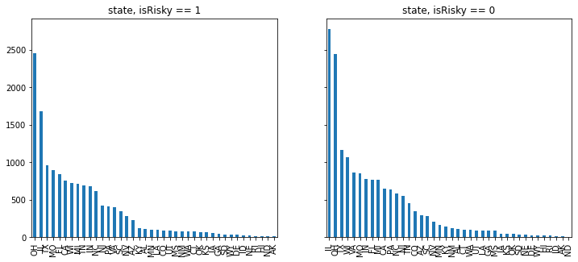

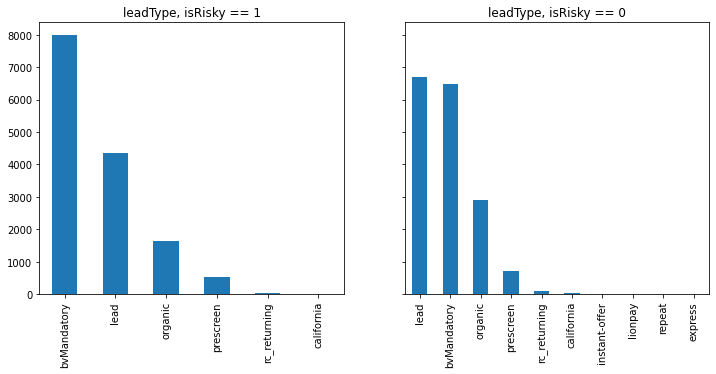

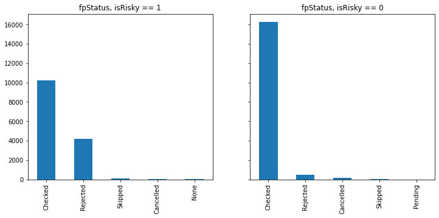

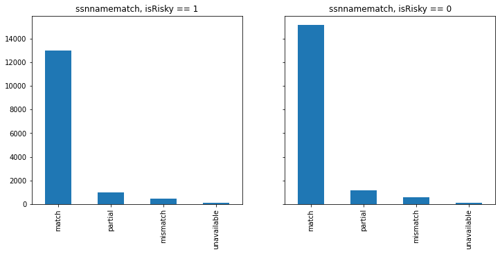

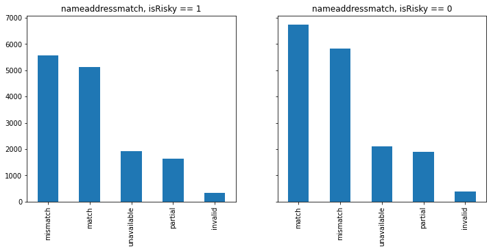

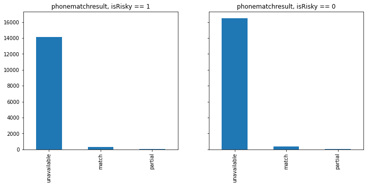

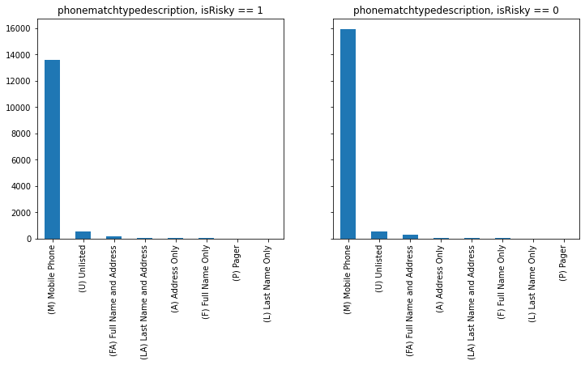

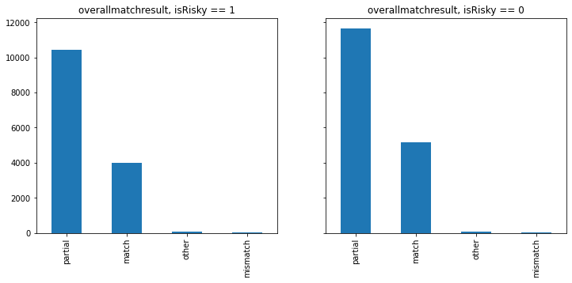

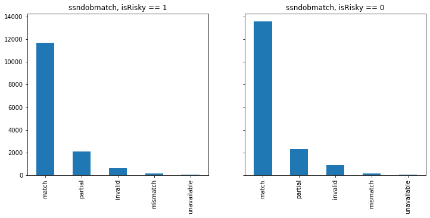

```python
# columns with many categories
columns_to_plot = ['state','leadType','fpStatus','ssnnamematch','nameaddressmatch','phonematchresult','phonematchtypedescription','overallmatchresult','ssndobmatch']
df_risky = df_combined[df_combined.isRisky == 1]
df_non_risky = df_combined[df_combined.isRisky == 0]

for col in columns_to_plot:

    fig, (ax1, ax2) = plt.subplots(1, 2, sharey=True)

    df_risky[col].value_counts().plot.bar(figsize=(12,5), ax=ax1)
    df_non_risky[col].value_counts().plot.bar(figsize=(12,5), ax=ax2)
    ax1.set_title(col+', isRisky == 1')
    ax2.set_title(col+', isRisky == 0')
    plt.show()
```

From the plots above, the categories are imbalanced (One category consists of very large portion while the others consists of many small portions)

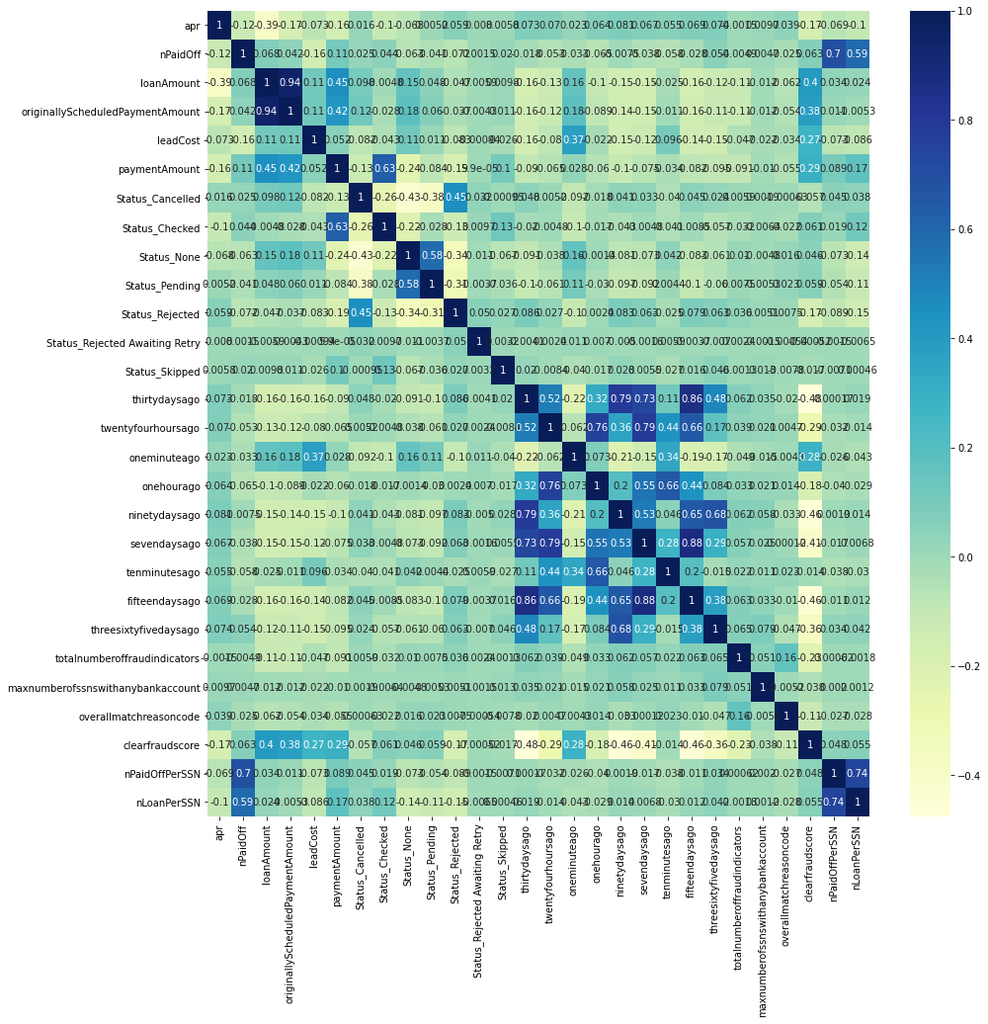

```python
fig, ax = plt.subplots(figsize=(15,15))
sns.heatmap(df_combined.drop(columns='isRisky').corr(), cmap="YlGnBu", annot=True, ax=ax)
```

From the correlation map above

1. `loanAmount` is highly correlated with `originallyScheduledPaymentAmount`
2. `thirtydaysago` is highly correlated with `fifteendaysago`
3. `sevendaysago` is highly correlated with `fifteendaysago`

```python
# drop highly correlated columns
columns_drop = ['originallyScheduledPaymentAmount','fifteendaysago']

df_combined.drop(columns=columns_drop, inplace=True)
```

```python
df_combined_clean_path = 'data/data/combined_clean.csv'
df_combined.to_csv(df_combined_clean_path, index=False)
```

### Data Preprocessing

[go back to the top]

In this part, I will prepare the data before feeding into model. In this case, I will convert categorical data and perform train-test split.

```python
df_combined = pd.read_csv('data/data/combined_clean.csv')

df_combined_info = df_combined.describe(include='all')
df_combined_info.loc['dtype'] = df_combined.dtypes
df_combined_info
```

|  | payFrequency | apr | nPaidOff | loanAmount | state | leadType | leadCost | fpStatus | paymentAmount | Status_Cancelled | Status_Checked | Status_None | Status_Pending | Status_Rejected | Status_Rejected Awaiting Retry | Status_Skipped | thirtydaysago | twentyfourhoursago | oneminuteago | onehourago | ninetydaysago | sevendaysago | tenminutesago | threesixtyfivedaysago | inquiryonfilecurrentaddressconflict | totalnumberoffraudindicators | telephonenumberinconsistentwithaddress | inquiryageyoungerthanssnissuedate | onfileaddresscautious | … |
| --- | --- | --- | --- | --- | --- | --- | --- | --- | --- | --- | --- | --- | --- | --- | --- | --- | --- | --- | --- | --- | --- | --- | --- | --- | --- | --- | --- | --- | --- | --- |
| count | 31508 | 31508.0 | 31508.0 | 31508.0 | 31508 | 31508 | 31508.0 | 31508 | 31508.0 | 31508.0 | 31508.0 | 31508.0 | 31508.0 | 31508.0 | 31508.0 | 31508.0 | 31508.0 | 31508.0 | 31508.0 | 31508.0 | 31508.0 | 31508.0 | 31508.0 | 31508.0 | 31508 | 31508.0 | 31508 | 31508 | 31508 | … |
| unique | 5 | NaN | NaN | NaN | 40 | 10 | NaN | 6 | NaN | NaN | NaN | NaN | NaN | NaN | NaN | NaN | NaN | NaN | NaN | NaN | NaN | NaN | NaN | NaN | 2 | NaN | 2 | 2 | 2 | … |
| top | B | NaN | NaN | NaN | OH | bvMandatory | NaN | Checked | NaN | NaN | NaN | NaN | NaN | NaN | NaN | NaN | NaN | NaN | NaN | NaN | NaN | NaN | NaN | NaN | False | NaN | True | False | False | … |
| freq | 18312 | NaN | NaN | NaN | 4895 | 14475 | NaN | 26514 | NaN | NaN | NaN | NaN | NaN | NaN | NaN | NaN | NaN | NaN | NaN | NaN | NaN | NaN | NaN | NaN | 23859 | NaN | 29458 | 31419 | 31506 | … |
| mean | NaN | 532.736433 | 0.168306 | 653.531516 | NaN | NaN | 13.958772 | NaN | 616.08694 | 6.726704 | 5.320617 | 4.068617 | 0.232512 | 0.844103 | 0.000444 | 0.090739 | 7.404596 | 4.651263 | 2.309604 | 4.024883 | 10.671956 | 5.487051 | 3.290656 | 20.419132 | NaN | 2.137108 | NaN | NaN | NaN | … |
| std | NaN | 128.266863 | 0.595379 | 491.235424 | NaN | NaN | 21.507714 | NaN | 745.517147 | 8.104707 | 6.051606 | 6.662368 | 0.47859 | 1.100444 | 0.022531 | 0.31897 | 6.477474 | 3.397064 | 1.438808 | 2.752888 | 10.644406 | 4.23752 | 2.147334 | 23.873162 | NaN | 1.246975 | NaN | NaN | NaN | … |
| min | NaN | 29.99 | 0.0 | 100.0 | NaN | NaN | 0.0 | NaN | 0.0 | 0.0 | 0.0 | 0.0 | 0.0 | 0.0 | 0.0 | 0.0 | 1.0 | 1.0 | 1.0 | 1.0 | 1.0 | 1.0 | 1.0 | 1.0 | NaN | 0.0 | NaN | NaN | NaN | … |
| 25% | NaN | 449.0 | 0.0 | 400.0 | NaN | NaN | 3.0 | NaN | 96.5 | 0.0 | 1.0 | 0.0 | 0.0 | 0.0 | 0.0 | 0.0 | 3.0 | 3.0 | 1.0 | 3.0 | 4.0 | 3.0 | 2.0 | 6.0 | NaN | 1.0 | NaN | NaN | NaN | … |
| 50% | NaN | 590.0 | 0.0 | 500.0 | NaN | NaN | 6.0 | NaN | 404.305 | 4.0 | 3.0 | 0.0 | 0.0 | 0.0 | 0.0 | 0.0 | 5.0 | 4.0 | 2.0 | 3.0 | 7.0 | 4.0 | 3.0 | 12.0 | NaN | 2.0 | NaN | NaN | NaN | … |
| 75% | NaN | 625.0 | 0.0 | 700.0 | NaN | NaN | 25.0 | NaN | 862.75 | 11.0 | 8.0 | 8.0 | 0.0 | 2.0 | 0.0 | 0.0 | 9.0 | 5.0 | 3.0 | 5.0 | 13.0 | 6.0 | 4.0 | 25.0 | NaN | 3.0 | NaN | NaN | NaN | … |
| max | NaN | 681.0 | 20.0 | 4687.0 | NaN | NaN | 200.0 | NaN | 8556.58 | 104.0 | 48.0 | 104.0 | 3.0 | 18.0 | 2.0 | 9.0 | 89.0 | 60.0 | 14.0 | 35.0 | 143.0 | 64.0 | 35.0 | 438.0 | NaN | 8.0 | NaN | NaN | NaN | … |
| dtype | object | float64 | float64 | float64 | object | object | int64 | object | float64 | int64 | int64 | int64 | int64 | int64 | int64 | int64 | float64 | float64 | float64 | float64 | float64 | float64 | float64 | float64 | bool | float64 | bool | bool | bool | … |

From the information above, I will convert the features below

| Type | Features |
| --- | --- |
| `Nominal` | `state`,`leadType`,`fpStatus`,`ssnnamematch`,`nameaddressmatch`,`phonematchresult`,`phonematchtypedescription`,`overallmatchresult`,`ssndobmatch` |
| `Ordinal` | `payFrequency` |

```python
# import sklearn libraries
from sklearn.model_selection import train_test_split, GridSearchCV

from sklearn.preprocessing import OneHotEncoder, OrdinalEncoder, LabelEncoder, StandardScaler
from sklearn.pipeline import Pipeline
from sklearn.compose import ColumnTransformer
from sklearn import set_config

from sklearn.linear_model import LogisticRegression
from sklearn.tree import DecisionTreeClassifier
from sklearn.ensemble import RandomForestClassifier, VotingClassifier

from sklearn.metrics import f1_score, precision_score, recall_score, plot_confusion_matrix
```

I will split the whole dataset into 3 different sets ($60\%$ training data, $20\%$ validation data and $20\%$ testing data)

```python
# split into x(features) and y(label)
df_X = df_combined.drop(columns='isRisky')
df_y = df_combined.isRisky

# split into 80% training data and 20% testing data
X_train, X_test, y_train, y_test = train_test_split(df_X, df_y,
    test_size=0.2, shuffle = True, random_state = 1)

# from 80% training data, split again into 75% training data and 25% validation data
X_train, X_valid, y_train, y_valid = train_test_split(X_train, y_train,
    test_size=0.25, shuffle = True, random_state = 1)

# in total i got 60% training data, 20% validation data and 20% testing data
```

```python
X_train.shape, X_valid.shape, X_test.shape, y_train.shape, y_valid.shape, y_test.shape
```

```
((18904, 56), (6302, 56), (6302, 56), (18904,), (6302,), (6302,))
```

```python
X_train.head()
```

|  | payFrequency | apr | nPaidOff | loanAmount | state | leadType | leadCost | fpStatus | paymentAmount | Status_Cancelled | Status_Checked | Status_None | Status_Pending | Status_Rejected | Status_Rejected Awaiting Retry | Status_Skipped | thirtydaysago | twentyfourhoursago | oneminuteago | onehourago | ninetydaysago | sevendaysago | tenminutesago | threesixtyfivedaysago | inquiryonfilecurrentaddressconflict | totalnumberoffraudindicators | telephonenumberinconsistentwithaddress | inquiryageyoungerthanssnissuedate | onfileaddresscautious | … |
| --- | --- | --- | --- | --- | --- | --- | --- | --- | --- | --- | --- | --- | --- | --- | --- | --- | --- | --- | --- | --- | --- | --- | --- | --- | --- | --- | --- | --- | --- | --- |
| 18790 | B | 645.0 | 0.0 | 400.0 | MN | bvMandatory | 3 | Checked | 95.97 | 11 | 1 | 0 | 0 | 1 | 0 | 0 | 5.0 | 4.0 | 4.0 | 4.0 | 10.0 | 5.0 | 4.0 | 23.0 | False | 2.0 | True | False | False | … |
| 29412 | W | 359.0 | 0.0 | 400.0 | VA | bvMandatory | 3 | Checked | 28.45 | 0 | 1 | 24 | 1 | 0 | 0 | 0 | 2.0 | 2.0 | 1.0 | 2.0 | 10.0 | 2.0 | 2.0 | 15.0 | False | 2.0 | True | False | False | … |
| 25987 | B | 590.0 | 0.0 | 700.0 | MO | lead | 25 | Checked | 963.63 | 12 | 2 | 0 | 0 | 0 | 0 | 0 | 4.0 | 3.0 | 3.0 | 3.0 | 4.0 | 3.0 | 3.0 | 4.0 | False | 1.0 | True | False | False | … |
| 4885 | S | 590.0 | 0.0 | 700.0 | MI | lead | 40 | Checked | 173.36 | 10 | 1 | 0 | 0 | 1 | 0 | 0 | 3.0 | 3.0 | 3.0 | 3.0 | 3.0 | 3.0 | 3.0 | 6.0 | False | 1.0 | True | False | False | … |
| 6904 | B | 590.0 | 0.0 | 500.0 | TN | bvMandatory | 6 | Checked | 112.43 | 9 | 1 | 0 | 0 | 2 | 0 | 0 | 32.0 | 7.0 | 1.0 | 7.0 | 32.0 | 8.0 | 2.0 | 34.0 | True | 2.0 | True | False | False | … |

```python
# create different preprocessing transformers
ohe = OneHotEncoder(handle_unknown='ignore')
binary_ohe = OneHotEncoder(drop='if_binary')
odn = OrdinalEncoder(categories=[['W','B','S','M','I']], handle_unknown='error')
# LabelEncoder() can only accept 2 positional arguments and 3 is passed in column transformer, so I change to ordinal encoder
# instead (They get the same result though the concept behind both encoder are different )
lbl = OrdinalEncoder()
scaler = StandardScaler()

# create lists of features based on their types
ohe_features = ['leadType','fpStatus', 'ssnnamematch','nameaddressmatch','phonematchresult','phonematchtypedescription',
                'overallmatchresult','ssndobmatch']
binary_ohe_features = ['inquiryonfilecurrentaddressconflict','telephonenumberinconsistentwithaddress',
                       'inquiryageyoungerthanssnissuedate','onfileaddresscautious','inquiryaddressnonresidential',
                       'onfileaddresshighrisk','ssnreportedmorefrequentlyforanother','currentaddressreportedbytradeopenlt90days',
                       'inputssnissuedatecannotbeverified','inquiryaddresscautious','morethan3inquiriesinthelast30days',
                       'onfileaddressnonresidential','creditestablishedpriortossnissuedate','driverlicenseformatinvalid',
                       'inquiryaddresshighrisk','inquirycurrentaddressnotonfile','highprobabilityssnbelongstoanother',
                       'currentaddressreportedbynewtradeonly','creditestablishedbeforeage18','telephonenumberinconsistentwithstate'
                      ]
odn_features = ['payFrequency']
lbl_features = ['state']
scaler_features = ['apr','nPaidOff','loanAmount','leadCost','paymentAmount','clearfraudscore']
```

Now, I will create a **`preprocessor`** using `ColumnTransformer`and pass in all the preprocessing steps inside it.

[output not shown]

- **`OneHotEncoder`**: Creates a list of columns based on number of category and assigns a value of 1 if the sample is belongs to that category
- **`OrdinalEncoder`**: Converts each sample into integer values and the encoded data represents the sequence of labels
- **`StandardScaler`**: Normalized the data using formula $Z = \frac{X-\mu}{\sigma}$

```python
preprocessor = ColumnTransformer(
    transformers = [
        ('ohe', ohe, ohe_features),
        ('binary_ohe', binary_ohe, binary_ohe_features),
        ('odn', odn, odn_features),
        ('lbl', lbl, lbl_features),
        ('scaler', scaler, scaler_features)
    ], remainder = 'passthrough'
)

set_config(display='diagram')
preprocessor
```

```python
# take a look at the first instance to examine it
preprocessor.fit_transform(X_train)[0]
```

```
array([ 1.        ,  0.        ,  0.        ,  0.        ,  0.        ,
        0.        ,  0.        ,  0.        ,  0.        ,  1.        ,
        0.        ,  0.        ,  0.        ,  0.        ,  1.        ,
        0.        ,  0.        ,  0.        ,  0.        ,  0.        ,
        1.        ,  0.        ,  0.        ,  0.        ,  0.        ,
        1.        ,  0.        ,  0.        ,  0.        ,  0.        ,
        0.        ,  1.        ,  0.        ,  0.        ,  0.        ,
        0.        ,  0.        ,  1.        ,  0.        ,  1.        ,
        0.        ,  0.        ,  0.        ,  0.        ,  1.        ,
        0.        ,  0.        ,  0.        ,  0.        ,  0.        ,
        0.        ,  0.        ,  0.        ,  0.        ,  0.        ,
        0.        ,  0.        ,  0.        ,  0.        ,  0.        ,
        0.        ,  0.        ,  0.        ,  1.        , 18.        ,
        0.87858395, -0.28960549, -0.51600132, -0.50504735, -0.6987674 ,
       -1.28584272, 11.        ,  1.        ,  0.        ,  0.        ,
        1.        ,  0.        ,  0.        ,  5.        ,  4.        ,
        4.        ,  4.        , 10.        ,  5.        ,  4.        ,
       23.        ,  2.        ,  5.        , 11.        ,  0.        ,
        1.        ])
```

### Model Building and Evaluation

[go back to the top]

Alright, now I've all done for the data preprocessing. It's time to feed the data into the model. I will use four different models for training.

1. Logistic Regression
2. Decision Tree
3. Random Forest
4. Voting

For the performance evaluation, it is important to accurately predict that the loan is risky (precision) at the same time detect as many risky loans as possible (recall). Therefore, I will use $f_{1}$ score as evaluation metric as I'm predicting whether the loan is risky or not. Here's are several reasons:

- $f_{1}$ score is combination of precision and recall into a single metric
- Harmonic mean of precision and recall
- Gives much more weight to low values
- Produces high score only if both precision and recall and high

```python
# create three different models
log_cf = LogisticRegression(max_iter=10000, random_state=1)
dec_cf = DecisionTreeClassifier(random_state=1)
rand_cf = RandomForestClassifier(random_state=1)
```

```python
# Make a pipeline for each classifier
log_pipeline = Pipeline(
    steps=[('preprocessor', preprocessor),('log_cf', log_cf)]
)

dec_pipeline = Pipeline(
    steps=[('preprocessor', preprocessor),('dec_cf', dec_cf)]
)

rand_pipeline = Pipeline(
    steps=[('preprocessor', preprocessor),('rand_cf', rand_cf)]
)
```

```python
# model training and evaluation
df_score = pd.DataFrame(columns=['model', 'train_accuracy','valid_accuracy', 'accuracy_difference', 'f1_score','precision','recall'])

pipelines = [log_pipeline, dec_pipeline, rand_pipeline]
names = ['Logistic Regression', 'Decision Tree', 'Random Forest']

i = 0
for pipeline in pipelines:
#   train model
    pipeline.fit(X_train, y_train)

#   get score
    train_score = pipeline.score(X_train, y_train)
    valid_score = pipeline.score(X_valid, y_valid)
    y_pred = pipeline.predict(X_valid)
    f1 = f1_score(y_valid, y_pred)
    precision = precision_score(y_valid, y_pred)
    recall = recall_score(y_valid, y_pred)

    dict = {
        'model': names[i],
        'train_accuracy': train_score,
        'valid_accuracy': valid_score,
        'accuracy_difference': train_score - valid_score,
        'f1_score': f1,
        'precision': precision,
        'recall': recall
    }
    df_score = df_score.append(dict, ignore_index=True)
    i+=1

df_score.sort_values(by='f1_score', ascending=False)
```

|  | model | train_accuracy | valid_accuracy | accuracy_difference | f1_score | precision | recall |
| --- | --- | --- | --- | --- | --- | --- | --- |
| 2 | Random Forest | 1.000000 | 0.908600 | 0.091400 | 0.896700 | 0.926956 | 0.868357 |
| 0 | Logistic Regression | 0.887854 | 0.887179 | 0.000676 | 0.872329 | 0.902974 | 0.843696 |
| 1 | Decision Tree | 1.000000 | 0.870200 | 0.129800 | 0.859257 | 0.851347 | 0.867315 |

Based on the result of 3 models, `Decision Tree` and `Random Forest` are **overfitting** with $100\%$ training accuracy, while the result of `Logistic Regression` is not so satisfactory. In this case, we try to combine all three classifiers using `Voting Classifier`

```python
vote_cf = VotingClassifier([('log_cf', log_cf),('dec_cf', dec_cf),
                            ('rand_cf', rand_cf)], voting='hard')

vote_pipeline = Pipeline(
    steps=[('preprocessor', preprocessor),('vote_cf', vote_cf)]
)

#   train model
vote_pipeline.fit(X_train, y_train)

#   get score
train_score = vote_pipeline.score(X_train, y_train)
valid_score = vote_pipeline.score(X_valid, y_valid)
y_pred = vote_pipeline.predict(X_valid)
f1 = f1_score(y_valid, y_pred)
precision = precision_score(y_valid, y_pred)
recall = recall_score(y_valid, y_pred)

dict = {
    'model': 'Voting',
    'train_accuracy': train_score,
    'valid_accuracy': valid_score,
    'accuracy_difference': train_score - valid_score,
    'f1_score': f1,
    'precision': precision,
    'recall': recall
}
df_score = df_score.append(dict, ignore_index=True)

df_score.sort_values(by='f1_score', ascending=False)
```

|  | model | train_accuracy | valid_accuracy | accuracy_difference | f1_score | precision | recall |
| --- | --- | --- | --- | --- | --- | --- | --- |
| 2 | Random Forest | 1.000000 | 0.908600 | 0.091400 | 0.896700 | 0.926956 | 0.868357 |
| 3 | Voting | 1.000000 | 0.906538 | 0.093462 | 0.894953 | 0.919721 | 0.871483 |
| 0 | Logistic Regression | 0.887854 | 0.887179 | 0.000676 | 0.872329 | 0.902974 | 0.843696 |
| 1 | Decision Tree | 1.000000 | 0.870200 | 0.129800 | 0.859257 | 0.851347 | 0.867315 |

Looks like `Voting Classifier` is overfitting as well. All four classifiers didn't get a satisfactory result. In this case, I'll import another model `XGBClassifier` from `XGBoost` which is an optimized [Gradient Boosting](https://machinelearningmastery.com/gentle-introduction-gradient-boosting-algorithm-machine-learning/) library for model training.

```python
from xgboost.sklearn import XGBClassifier

xgb_cf = XGBClassifier(random_state=1)
xgb_pipeline = Pipeline(
    steps=[('preprocessor', preprocessor),('xgb_cf', xgb_cf)]
)

#   train model
xgb_pipeline.fit(X_train, y_train)

#   get score
train_score = xgb_pipeline.score(X_train, y_train)
valid_score = xgb_pipeline.score(X_valid, y_valid)
y_pred = vote_pipeline.predict(X_valid)
f1 = f1_score(y_valid, y_pred)
precision = precision_score(y_valid, y_pred)
recall = recall_score(y_valid, y_pred)

dict = {
    'model': 'XGB',
    'train_accuracy': train_score,
    'valid_accuracy': valid_score,
    'accuracy_difference': train_score - valid_score,
    'f1_score': f1,
    'precision': precision,
    'recall': recall
}
df_score = df_score.append(dict, ignore_index=True)

df_score.sort_values(by='f1_score', ascending=False)
```

|  | model | train_accuracy | valid_accuracy | accuracy_difference | f1_score | precision | recall |
| --- | --- | --- | --- | --- | --- | --- | --- |
| 2 | Random Forest | 1.000000 | 0.908600 | 0.091400 | 0.896700 | 0.926956 | 0.868357 |
| 3 | Voting | 1.000000 | 0.906538 | 0.093462 | 0.894953 | 0.919721 | 0.871483 |
| 4 | XGB | 0.969742 | 0.914154 | 0.055588 | 0.894953 | 0.919721 | 0.871483 |
| 0 | Logistic Regression | 0.887854 | 0.887179 | 0.000676 | 0.872329 | 0.902974 | 0.843696 |
| 1 | Decision Tree | 1.000000 | 0.870200 | 0.129800 | 0.859257 | 0.851347 | 0.867315 |

First, I will get feature importances from `XGBClassifier`. Then, given a set of thresholds, I will try to drop some features if the importance is less than the specific threshold and determine which model performs the best. Below code is a function to get feature names from the preprocessor after being transform (ColumnTransformer's get_feature_names() fails if at least one transformer does not create new columns) The original code of the function is [here](https://johaupt.github.io/blog/columnTransformer_feature_names.html).

```python
import warnings

def get_feature_names(column_transformer):
    """Get feature names from all transformers.
    Returns
    -------
    feature_names : list of strings
        Names of the features produced by transform.
    """
    # Remove the internal helper function
    #check_is_fitted(column_transformer)

    # Turn loopkup into function for better handling with pipeline later
    def get_names(trans):
        # >> Original get_feature_names() method
        if trans == 'drop' or (
                hasattr(column, '__len__') and not len(column)):
            return []
        if trans == 'passthrough':
            if hasattr(column_transformer, '_df_columns'):
                if ((not isinstance(column, slice))
                        and all(isinstance(col, str) for col in column)):
                    return column
                else:
                    return column_transformer._df_columns[column]
            else:
                indices = np.arange(column_transformer._n_features)
                return ['x%d' % i for i in indices[column]]
        if not hasattr(trans, 'get_feature_names'):
        # >>> Change: Return input column names if no method avaiable
            # Turn error into a warning
            warnings.warn("Transformer %s (type %s) does not "
                                 "provide get_feature_names. "
                                 "Will return input column names if available"
                                 % (str(name), type(trans).__name__))
            # For transformers without a get_features_names method, use the input
            # names to the column transformer
            if column is None:
                return []
            else:
                return [name + "__" + f for f in column]

        return [name + "__" + f for f in trans.get_feature_names()]

    ### Start of processing
    feature_names = []

    # Allow transformers to be pipelines. Pipeline steps are named differently, so preprocessing is needed
    if type(column_transformer) == sklearn.pipeline.Pipeline:
        l_transformers = [(name, trans, None, None) for step, name, trans in column_transformer._iter()]
    else:
        # For column transformers, follow the original method
        l_transformers = list(column_transformer._iter(fitted=True))


    for name, trans, column, _ in l_transformers:
        if type(trans) == sklearn.pipeline.Pipeline:
            # Recursive call on pipeline
            _names = get_feature_names(trans)
            # if pipeline has no transformer that returns names
            if len(_names)==0:
                _names = [name + "__" + f for f in column]
            feature_names.extend(_names)
        else:
            feature_names.extend(get_names(trans))

    return feature_names
```

```python
# retrieve feature importances
feature_importances = xgb_cf.feature_importances_

# retrieve feature names
feature_names = get_feature_names(preprocessor)

# merge into single dataframe
temp = pd.DataFrame(data=feature_names, columns=['feature_names'])
df_imp = pd.DataFrame(data=feature_importances, columns=['feature_importances'])
df_imp = temp.merge(df_imp, left_index=True, right_index=True).reset_index().sort_values(by='feature_importances', ascending=False)
df_imp[:10]
```

|  | index | feature_names | feature_importances |
| --- | --- | --- | --- |
| 75 | 75 | Status_Rejected | 0.510893 |
| 12 | 12 | ohe__x1_Rejected | 0.067423 |
| 9 | 9 | ohe__x1_Checked | 0.034037 |
| 71 | 71 | Status_Cancelled | 0.026131 |
| 69 | 69 | scaler__paymentAmount | 0.018912 |
| 66 | 66 | scaler__nPaidOff | 0.017295 |
| 77 | 77 | Status_Skipped | 0.017037 |
| 90 | 90 | nLoanPerSSN | 0.015308 |
| 73 | 73 | Status_None | 0.011918 |
| 74 | 74 | Status_Pending | 0.011619 |

From the dataframe above, it seems that `Status_Rejected` contributes a lot to the prediction (with $51\%$) followed by `fpStatus_Rejected` (with $6.7\%$), `fp_Status_Checked` (with $3.4\%$), `Status_Cancelled` (with $2.6\%$) and `paymentAmount` (with $1.9\%$).

```python
xgb_cf = XGBClassifier(random_state=1)

df_score = pd.DataFrame(columns=['threshold', 'number_of_dropped_columns', 'train_accuracy', 'valid_accuracy', 'accuracy_difference', 'f1_score','precision','recall'])

# set of thresholds
thresholds = [0.01, 0.001, 0.0001, 0]

# train the model given the threshold
for threshold in thresholds:
    drop_columns = df_imp.loc[df_imp.feature_importances < threshold, ['index']].values
    drop_columns = [item for sublist in drop_columns for item in sublist]
    preprocessor_2 = ColumnTransformer([("drop", "drop", drop_columns)], remainder='passthrough')
    xgb_pipeline = Pipeline(
    steps=[('preprocessor', preprocessor),
           ('preprocessor_2', preprocessor_2),
           ('xgb_cf', xgb_cf)
          ])
    xgb_pipeline.fit(X_train, y_train)

    train_score = xgb_pipeline.score(X_train, y_train)
    valid_score = xgb_pipeline.score(X_valid, y_valid)
    y_pred = xgb_pipeline.predict(X_valid)
    f1 = f1_score(y_valid, y_pred)
    precision = precision_score(y_valid, y_pred)
    recall = recall_score(y_valid, y_pred)
    dict = {
        'threshold': threshold,
        'number_of_dropped_columns': len(drop_columns),
        'train_accuracy': train_score,
        'valid_accuracy': valid_score,
        'accuracy_difference': train_score - valid_score,
        'f1_score': f1,
        'precision': precision,
        'recall': recall
    }
    df_score = df_score.append(dict, ignore_index=True)

df_score.sort_values(by='f1_score', ascending=False)
```

|  | threshold | number_of_dropped_columns | train_accuracy | valid_accuracy | accuracy_difference | f1_score | precision | recall |
| --- | --- | --- | --- | --- | --- | --- | --- | --- |
| 1 | 0.0010 | 20.0 | 0.969953 | 0.914630 | 0.055323 | 0.904100 | 0.928598 | 0.880861 |
| 2 | 0.0001 | 19.0 | 0.969742 | 0.914154 | 0.055588 | 0.903548 | 0.928205 | 0.880167 |
| 3 | 0.0000 | 0.0 | 0.969742 | 0.914154 | 0.055588 | 0.903548 | 0.928205 | 0.880167 |
| 0 | 0.0100 | 78.0 | 0.938902 | 0.912885 | 0.026017 | 0.901982 | 0.927994 | 0.877388 |

From the table above, threshold `0.001` produces the best result for all metrics (but still a bit of overfitting as training accuracy is 0.05 higher than validation accuracy). So, we will use **XGBoost Classifier** with `0.001` threshold as our model. For the next step, I will search to find for optimum hyperparameters. In this case, I didn't use `GridSearchCV` as there will be missing categories if I split the data into `KFold` (For example one category exists in certain fold but not the other folds as the number of the specific category is too less). Therefore, I code a similar function to `GridSearchCV` without using `KFold`.

#### Reminder: following cell takes about 20 - 30 minutes to execute

```python
xgb_cf__eta = [0.01, 0.1, 0.2, 0.3]
xgb_cf__gamma = [0.01, 0.1, 1]
xgb_cf__max_depth = [3, 5, 7, 10]
xgb_cf__min_child_weight = [1, 3, 5]
xgb_cf__subsample = [0.6, 0.8, 1.0]

drop_columns = df_imp.loc[df_imp.feature_importances < 0.001, ['index']].values
drop_columns = [item for sublist in drop_columns for item in sublist]
preprocessor_2 = ColumnTransformer([("drop", "drop", drop_columns)], remainder='passthrough')

df_grid = pd.DataFrame(columns=['eta', 'gamma', 'max_depth', 'min_child_weight', 'subsample', 'train_accuracy',
                                 'valid_accuracy', 'accuracy_difference', 'f1_score','precision','recall'])

from time import time

i = 1
for eta in xgb_cf__eta:
    for gamma in xgb_cf__gamma:
        for max_depth in xgb_cf__max_depth:
            for min_child_weight in xgb_cf__min_child_weight:
                for subsample in xgb_cf__subsample:

                    t1 = time()

                    xgb_cf = XGBClassifier(random_state=1, eta=eta, gamma=gamma, max_depth=max_depth, min_child_weight=min_child_weight, subsample=subsample)
                    xgb_pipeline = Pipeline(steps=[('preprocessor', preprocessor), ('preprocessor_2', preprocessor_2),
                                                   ('xgb_cf', xgb_cf)])
                    xgb_pipeline.fit(X_train, y_train)

                    train_score = xgb_pipeline.score(X_train, y_train)
                    valid_score = xgb_pipeline.score(X_valid, y_valid)
                    y_pred = xgb_pipeline.predict(X_valid)
                    f1 = f1_score(y_valid, y_pred)
                    precision = precision_score(y_valid, y_pred)
                    recall = recall_score(y_valid, y_pred)

                    dict = {
                        'eta': eta,
                        'gamma': gamma,
                        'max_depth': max_depth,
                        'min_child_weight': min_child_weight,
                        'subsample': subsample,
                        'train_accuracy': train_score,
                        'valid_accuracy': valid_score,
                        'accuracy_difference': train_score - valid_score,
                        'f1_score': f1,
                        'precision': precision,
                        'recall': recall
                    }

                    df_grid = df_grid.append(dict, ignore_index=True)

                    t2 = time()
                    elapsed = t2 - t1
                    print(f'#{i}: Elapsed time is {elapsed:.2f} seconds.')
                    i += 1
```

[output not shown]

[output cut: 377 more lines]

```
#418: Elapsed time is 3.52 seconds.
#419: Elapsed time is 3.17 seconds.
#420: Elapsed time is 2.98 seconds.
#421: Elapsed time is 3.31 seconds.
#422: Elapsed time is 3.28 seconds.
#423: Elapsed time is 3.39 seconds.
#424: Elapsed time is 5.49 seconds.
#425: Elapsed time is 4.40 seconds.
#426: Elapsed time is 4.04 seconds.
#427: Elapsed time is 4.39 seconds.
#428: Elapsed time is 4.39 seconds.
#429: Elapsed time is 3.98 seconds.
#430: Elapsed time is 4.30 seconds.
#431: Elapsed time is 4.44 seconds.
#432: Elapsed time is 3.91 seconds.
```

```python
df_grid.sort_values(by=['f1_score', 'precision', 'recall','valid_accuracy','accuracy_difference'], ascending=[False,False,False,False,True])
```

|  | eta | gamma | max_depth | min_child_weight | subsample | train_accuracy | valid_accuracy | accuracy_difference | f1_score | precision | recall |
| --- | --- | --- | --- | --- | --- | --- | --- | --- | --- | --- | --- |
| 136 | 0.10 | 0.01 | 10.0 | 1.0 | 0.8 | 0.988362 | 0.917804 | 0.070558 | 0.907268 | 0.936092 | 0.880167 |
| 179 | 0.10 | 0.10 | 10.0 | 5.0 | 1.0 | 0.965669 | 0.917328 | 0.048341 | 0.906815 | 0.934735 | 0.880514 |
| 203 | 0.10 | 1.00 | 7.0 | 3.0 | 1.0 | 0.946837 | 0.917645 | 0.029191 | 0.906671 | 0.939970 | 0.875651 |
| 201 | 0.10 | 1.00 | 7.0 | 3.0 | 0.6 | 0.946043 | 0.917487 | 0.028557 | 0.906576 | 0.938965 | 0.876346 |
| 164 | 0.10 | 0.10 | 7.0 | 1.0 | 1.0 | 0.954348 | 0.917645 | 0.036703 | 0.906503 | 0.941617 | 0.873915 |
| ... | ... | ... | ... | ... | ... | ... | ... | ... | ... | ... | ... |
| 39 | 0.01 | 0.10 | 3.0 | 3.0 | 0.6 | 0.896636 | 0.897175 | -0.000540 | 0.885350 | 0.902272 | 0.869052 |
| 42 | 0.01 | 0.10 | 3.0 | 5.0 | 0.6 | 0.896636 | 0.897175 | -0.000540 | 0.885350 | 0.902272 | 0.869052 |
| 72 | 0.01 | 1.00 | 3.0 | 1.0 | 0.6 | 0.896636 | 0.897175 | -0.000540 | 0.885350 | 0.902272 | 0.869052 |
| 75 | 0.01 | 1.00 | 3.0 | 3.0 | 0.6 | 0.896636 | 0.897175 | -0.000540 | 0.885350 | 0.902272 | 0.869052 |
| 78 | 0.01 | 1.00 | 3.0 | 5.0 | 0.6 | 0.896636 | 0.897175 | -0.000540 | 0.885350 | 0.902272 | 0.869052 |

432 rows × 11 columns

From the table above, the model with the highest f1_score got a $7\%$ difference between training accuracy and validation accuracy which is quite high compared to the others. Therefore, I will select the model with a high `f1_score` and came with a small accuracy difference. For model #203, the $f_{1}$ score is `0.906671` which is $\approx 0.0006$ lower than the highest but it comes with a much lower accuracy difference. By considering the trade-off between them, I decide to choose this model as the final model.

| Hyperparameter | Value |
| --- | --- |
| `eta` | `0.1` |
| `gamma` | `1` |
| `max_depth` | `7` |
| `min_child_weight` | `3` |
| `subsample` | `1` |

Again, let's train again our final model.

```python
drop_columns = df_imp.loc[df_imp.feature_importances < 0.001, ['index']].values
drop_columns = [item for sublist in drop_columns for item in sublist]
preprocessor_2 = ColumnTransformer([("drop", "drop", drop_columns)], remainder='passthrough')
xgb_cf = XGBClassifier(random_state=1, eta=0.1, gamma=1, max_depth=7, min_child_weight=3, subsample=1)

final_pipeline = Pipeline(steps=[('preprocessor', preprocessor), ('preprocessor_2', preprocessor_2), ('xgb_cf', xgb_cf)])
final_pipeline.fit(X_train, y_train)
```

Let's look at the confusion matrix of the final model.

```
<sklearn.metrics._plot.confusion_matrix.ConfusionMatrixDisplay at 0x23f4bb891f0>
```

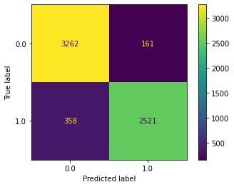

```python
plot_confusion_matrix(final_pipeline, X_valid, y_valid)
```

From the confusion matrix above,

- There is 358 out of 2879 (358+2521) of risky loan (with label 1) is predicted as non-risky loan (with label 0)
- For 2682 predicted as risky loan (with label 1), there is 161 is actually non-risky loan (with label 0)

And at the very final, let's predict on the testing data (Data that is never seen before & never used to fine tune the model)

```python
final_score = pd.DataFrame(columns=['model', 'accuracy', 'f1_score','precision','recall'])

test_score = final_pipeline.score(X_test, y_test)
y_pred = final_pipeline.predict(X_test)
f1 = f1_score(y_test, y_pred)
precision = precision_score(y_test, y_pred)
recall = recall_score(y_test, y_pred)

dict = {
    'model': 'XGB',
    'accuracy': test_score,
    'f1_score': f1,
    'precision': precision,
    'recall': recall
}
final_score = final_score.append(dict, ignore_index=True)

final_score
```

|  | model | accuracy | f1_score | precision | recall |
| --- | --- | --- | --- | --- | --- |
| 0 | XGB | 0.919232 | 0.908993 | 0.941481 | 0.878673 |

The f1_score even perform slightly better than of validation set. This proves that the model is not overfitting.  
Let's look at the confusion matrix as well.

```
<sklearn.metrics._plot.confusion_matrix.ConfusionMatrixDisplay at 0x23f4bd15e80>
```

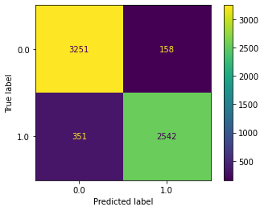

```python
plot_confusion_matrix(final_pipeline, X_test, y_test)
```

Well, this looks a lot similar to the previous confusion matrix.

### Export the Model

[go back to the top]

Now, it's time to the final step which is to export the model.

```python
!mkdir model
```

```
A subdirectory or file model already exists.
```

```python
joblib.dump(final_pipeline, 'model/XGBClassifier.joblib')
```

```
['model/XGBClassifier.joblib']
```

```python
# verify model persistency
clf = joblib.load('model/XGBClassifier.joblib')

final_score = pd.DataFrame(columns=['model', 'accuracy', 'f1_score','precision','recall'])

test_score = clf.score(X_test, y_test)
y_pred = clf.predict(X_test)
f1 = f1_score(y_test, y_pred)
precision = precision_score(y_test, y_pred)
recall = recall_score(y_test, y_pred)

dict = {
    'model': 'XGB',
    'accuracy': test_score,
    'f1_score': f1,
    'precision': precision,
    'recall': recall
}
final_score = final_score.append(dict, ignore_index=True)

final_score
```

|  | model | accuracy | f1_score | precision | recall |
| --- | --- | --- | --- | --- | --- |
| 0 | XGB | 0.919232 | 0.908993 | 0.941481 | 0.878673 |

### Final Notes

[go back to the top]

Some final thoughts about the data, model and further improvements

- Feature engineering and data preprocessing are solely based on personal knowledge and assumption including defining a risky loan and this may lead to a highly biased model
- More knowledge on finance especially in the context of loan is needed in order to create better features from the dataset
- It is hard to find the relationship that differs between risky and non-risky loan as the distribution for both side are similar and this may be the reason of `status_rejected` scores the highest in the model feature importances and contribute for about $51\%$ as this feature differs the most
- Payment status, effective payment amount, first payment status and number of paid off loan are the most important factors to predict risky loan (Refer to feature importances table) but in real world situation, we will not know their payment status, effective payment amount and first payment status if we didn't approve the loan at first. This may be the limitation of the model usage where we can only predict the client that has receive loans before from the company (where their past data are available)
- In real world, risky loan consists of only a small portion which is harder to be trained since the class is imbalance and it is needed to collect more data or using up-sampling technique the get a better model result
- The model can be tuned towards `recall` metric as we have to capture more possible risky loans

### Extras

Total time taken to complete the task: Roughly 35 hours